# Metrics for assessing community assembly processes

```r
source('../env.R')
```

[output not shown]

[output not shown]

```r
3
```

[output not shown]

[output not shown]

```r
community_data = read_csv(filename(COMMUNITY_OUTPUT_DIR, 'community_assembly_metrics_using_relative_abundance.csv'))
head(community_data)
```

| mntd_standard | mntd_normal | mntd_actual | mass_fdiv_standard | mass_fdiv_normal | mass_fdiv_actual | beak_width_fdiv_standard | beak_width_fdiv_normal | beak_width_fdiv_actual | hwi_fdiv_standard | hwi_fdiv_normal | hwi_fdiv_actual | city_id | urban_pool_size |
| --- | --- | --- | --- | --- | --- | --- | --- | --- | --- | --- | --- | --- | --- |
| -0.08438945 | 0.4659133138 | 47.04785 | 1.37531261 | 0.9361477 | 0.9327475 | -0.80925060 | 0.3524538 | 0.5703226 | 1.00663213 | 0.918421140 | 0.9278417 | 10 | 4 |
| -1.07619786 | 0.0036782647 | 28.83967 | -0.09860278 | 0.4820179 | 0.6753132 | 0.36797475 | 0.5961729 | 0.6260099 | -0.16593911 | 0.489193293 | 0.4380120 | 14 | 6 |
| 1.63777989 | 0.9960546075 | 52.20504 | 0.76048201 | 0.9182750 | 0.9502773 | 0.43528594 | 0.6996758 | 0.6606758 | -1.63630867 | 0.003018843 | 0.9081184 | 19 | 4 |
| -0.90773964 | 0.0007161845 | 28.78871 | -0.53300378 | 0.3887914 | 0.6024865 | 0.09177454 | 0.5386981 | 0.5774231 | -0.08957252 | 0.473298307 | 0.4435131 | 21 | 6 |
| 0.18408771 | 0.5922945937 | 49.53917 | 0.87068314 | 0.8012420 | 0.9024739 | -0.69181695 | 0.3293775 | 0.5586867 | 0.87907494 | 0.879783599 | 0.9178214 | 29 | 4 |
| 1.32387887 | 0.9922388335 | 51.11582 | 0.30305958 | 0.5951469 | 0.9313592 | -0.23197131 | 0.4162648 | 0.5523798 | -1.32627501 | 0.002850628 | 0.9119568 | 46 | 4 |

```r
colnames(community_data)
```

```
 [1] "mntd_standard"            "mntd_normal"              "mntd_actual"              "mass_fdiv_standard"
 [5] "mass_fdiv_normal"         "mass_fdiv_actual"         "beak_width_fdiv_standard" "beak_width_fdiv_normal"
 [9] "beak_width_fdiv_actual"   "hwi_fdiv_standard"        "hwi_fdiv_normal"          "hwi_fdiv_actual"
[13] "city_id"                  "urban_pool_size"
```

```r
min(community_data$mntd_standard)
```

```
[1] -2.338219
```

```r
max(community_data$mntd_standard)
```

```
[1] 2.34743
```

```r
min(community_data$beak_width_fdiv_standard)
```

```
[1] -2.685152
```

```r
max(community_data$beak_width_fdiv_standard)
```

```
[1] 1.931681
```

```r
min(community_data$hwi_fdiv_standard)
```

```
[1] -2.254896
```

```r
max(community_data$hwi_fdiv_standard)
```

```
[1] 2.315362
```

```r
min(community_data$mass_fdiv_standard)
```

```
[1] -2.351968
```

```r
max(community_data$mass_fdiv_standard)
```

```
[1] 2.114779
```

```r
min(community_data$mntd_normal)
```

```
[1] 0
```

```r
max(community_data$mntd_normal)
```

```
[1] 1
```

```r
min(community_data$beak_width_fdiv_normal)
```

```
[1] 0
```

```r
max(community_data$beak_width_fdiv_normal)
```

```
[1] 1
```

```r
min(community_data$hwi_fdiv_normal)
```

```
[1] 0
```

```r
max(community_data$hwi_fdiv_normal)
```

```
[1] 1
```

```r
min(community_data$mass_fdiv_normal)
```

```
[1] 0
```

```r
max(community_data$mass_fdiv_normal)
```

```
[1] 1
```

Join on realms

```r
city_to_realm = read_csv(filename(CITY_DATA_OUTPUT_DIR, 'realms.csv'))
community_data_with_realm = left_join(community_data, city_to_realm)
```

Cities as points

```r
city_points = st_centroid(read_sf(filename(CITY_DATA_OUTPUT_DIR, 'city_selection.shp'))) %>% left_join(community_data_with_realm)
city_points_coords = st_coordinates(city_points)
city_points$latitude = city_points_coords[,1]
city_points$longitude = city_points_coords[,2]
```

```r
world_map = read_country_boundaries()
```

Load community data, and create long format version

```r
communities = read_csv(filename(COMMUNITY_OUTPUT_DIR, 'communities_for_analysis.csv'))
communities
```

| city_id | city_name | ebird_species_name | seasonal | presence | origin | relative_abundance_proxy |
| --- | --- | --- | --- | --- | --- | --- |
| 1 | Honolulu | Columba livia | Resident | Extant | Introduced | 47.24367142 |
| 1 | Honolulu | Spilopelia chinensis | Resident | Extant | Introduced | 81.10229942 |
| 10 | San Jose | Columba livia | Resident | Extant | Introduced | 50.45307481 |
| 10 | San Jose | Columbina passerina | Passage | Extant | Native | 0.00000000 |
| 10 | San Jose | Patagioenas fasciata | Resident | Extant | Native | 19.23186789 |
| 10 | San Jose | Streptopelia decaocto | Resident | Extant | Introduced | 30.98684185 |
| 10 | San Jose | Zenaida macroura | Resident | Extant | Native | 65.18338926 |
| 14 | Los Angeles | Columba livia | Resident | Extant | Introduced | 32.51206992 |
| 14 | Los Angeles | Columbina passerina | Resident | Extant | Native | 0.26953190 |
| 14 | Los Angeles | Patagioenas fasciata | Resident | Extant | Native | 16.53723578 |

[output cut: 990 more lines]

```r
community_summary = communities %>% group_by(city_id) %>% summarise(regional_pool_size = n(), urban_pool_size = sum(relative_abundance_proxy > 0))
community_summary
```

| city_id | regional_pool_size | urban_pool_size |
| --- | --- | --- |
| 1 | 2 | 2 |
| 10 | 5 | 4 |
| 14 | 6 | 6 |
| 19 | 4 | 4 |
| 21 | 6 | 6 |
| 29 | 5 | 4 |
| 46 | 4 | 4 |
| 49 | 4 | 4 |
| 57 | 6 | 5 |
| 65 | 7 | 6 |

[output cut: 327 more lines]

Load trait data

```r
traits = read_csv(filename(TAXONOMY_OUTPUT_DIR, 'traits_ebird.csv'))
head(traits)
```

| ebird_species_name | beak_width | hwi | mass | habitat | habitat_density | migration | trophic_level | trophic_niche | primary_lifestyle |
| --- | --- | --- | --- | --- | --- | --- | --- | --- | --- |
| Alectroenas madagascariensis | 4.1 | 33.6 | 173.0 | Forest | 2 | 1 | Herbivore | Frugivore | Insessorial |
| Alectroenas pulcherrimus | 4.5 | 25.2 | 165.0 | Forest | 2 | 1 | Herbivore | Frugivore | Insessorial |
| Alectroenas sganzini | 4.4 | 30.7 | 158.0 | Forest | 2 | 1 | Herbivore | Frugivore | Insessorial |
| Pampusana beccarii | 2.4 | 29.2 | 78.7 | Forest | 1 | 1 | Herbivore | Omnivore | Terrestrial |
| Pampusana canifrons | 2.8 | 26.5 | 135.0 | Forest | 1 | 1 | Herbivore | Granivore | Terrestrial |
| Pampusana erythroptera | 3.6 | 30.8 | 113.2 | Woodland | 1 | 1 | Herbivore | Granivore | Terrestrial |

Load spatial var

```r
spatial_var = read_csv(filename(COMMUNITY_OUTPUT_DIR, 'spatial_var.csv')) %>% filter(city_id %in% community_summary$city_id)
spatial_var
```

| city_id | NMDS1 | NMDS2 |
| --- | --- | --- |
| 1 | -0.251730413 | -0.500280099 |
| 10 | 0.426998804 | -0.300302074 |
| 14 | 0.484890377 | -0.388036982 |
| 19 | 0.316195205 | -0.138549561 |
| 21 | 0.484890377 | -0.388036982 |
| 29 | 0.426998804 | -0.300302074 |
| 46 | 0.316195205 | -0.138549561 |
| 49 | 0.316195205 | -0.138549561 |
| 57 | 0.484890377 | -0.388036982 |
| 65 | 0.497962083 | -0.581799469 |

[output cut: 327 more lines]

# Summary metrics by Realm

```r
test_required_values = function(name, df) {
  cat(paste(
    test_value_wilcox(paste(name, 'Std: MNTD'), df$mntd_standard),
    test_value_wilcox(paste(name, 'Std: Beak Width FDiv'), df$beak_width_fdiv_standard),
    test_value_wilcox(paste(name, 'Std: HWI FDiv'), df$hwi_fdiv_standard),
    test_value_wilcox(paste(name, 'Std: Mass FDiv'), df$mass_fdiv_standard),

    test_value_wilcox(paste(name, 'Norm: MNTD'), df$mntd_normal, mu = 0.5),
    test_value_wilcox(paste(name, 'Norm: Beak Width FDiv'), df$beak_width_fdiv_normal, mu = 0.5),
    test_value_wilcox(paste(name, 'Norm: HWI FDiv'), df$hwi_fdiv_normal, mu = 0.5),
    test_value_wilcox(paste(name, 'Norm: Mass FDiv'), df$mass_fdiv_normal, mu = 0.5),
    paste('N', nrow(df)),
    sep = "\n"))
}
```

```r
test_required_values('Global', community_data_with_realm)
```

```
Global Std: MNTD median -0.36 ***
Global Std: Beak Width FDiv median 0.03
Global Std: HWI FDiv median 0.39 **
Global Std: Mass FDiv median 0.29 ***
Global Norm: MNTD median 0.38 ***
Global Norm: Beak Width FDiv median 0.59 ***
Global Norm: HWI FDiv median 0.64 ***
Global Norm: Mass FDiv median 0.64 ***
N 308
```

```r
unique(community_data_with_realm$core_realm)
```

```
[1] "Nearctic"    "Neotropic"   "Palearctic"  "Afrotropic"  "Indomalayan" "Australasia"
```

```r
test_required_values('Nearctic', community_data_with_realm[community_data_with_realm$core_realm == 'Nearctic',])
```

```
Nearctic Std: MNTD median 0.67 *
Nearctic Std: Beak Width FDiv median 0.29
Nearctic Std: HWI FDiv median -0.8 ***
Nearctic Std: Mass FDiv median -0.26
Nearctic Norm: MNTD median 0.75
Nearctic Norm: Beak Width FDiv median 0.62
Nearctic Norm: HWI FDiv median 0.23 **
Nearctic Norm: Mass FDiv median 0.48
N 46
```

```r
test_required_values('Neotropic', community_data_with_realm[community_data_with_realm$core_realm == 'Neotropic',])
```

```
Neotropic Std: MNTD median 0.03
Neotropic Std: Beak Width FDiv median -0.44 ***
Neotropic Std: HWI FDiv median -0.31
Neotropic Std: Mass FDiv median 0.33 *
Neotropic Norm: MNTD median 0.45
Neotropic Norm: Beak Width FDiv median 0.46
Neotropic Norm: HWI FDiv median 0.5
Neotropic Norm: Mass FDiv median 0.65 ***
N 64
```

```r
test_required_values('Palearctic', community_data_with_realm[community_data_with_realm$core_realm == 'Palearctic',])
```

```
Palearctic Std: MNTD median 0.13
Palearctic Std: Beak Width FDiv median 1.25 ***
Palearctic Std: HWI FDiv median -0.39
Palearctic Std: Mass FDiv median 0.01
Palearctic Norm: MNTD median 0.57 *
Palearctic Norm: Beak Width FDiv median 0.93 ***
Palearctic Norm: HWI FDiv median 0.38
Palearctic Norm: Mass FDiv median 0.55
N 72
```

```r
test_required_values('Afrotropic', community_data_with_realm[community_data_with_realm$core_realm == 'Afrotropic',])
```

```
Afrotropic Std: MNTD median -1.27 *
Afrotropic Std: Beak Width FDiv median -0.5
Afrotropic Std: HWI FDiv median 0.17
Afrotropic Std: Mass FDiv median -0.95
Afrotropic Norm: MNTD median 0.07 *
Afrotropic Norm: Beak Width FDiv median 0.42
Afrotropic Norm: HWI FDiv median 0.54
Afrotropic Norm: Mass FDiv median 0.34
N 9
```

```r
test_required_values('Indomalayan', community_data_with_realm[community_data_with_realm$core_realm == 'Indomalayan',])
```

```
Indomalayan Std: MNTD median -0.63 ***
Indomalayan Std: Beak Width FDiv median -0.7 ***
Indomalayan Std: HWI FDiv median 1.11 ***
Indomalayan Std: Mass FDiv median 0.84 ***
Indomalayan Norm: MNTD median 0.21 ***
Indomalayan Norm: Beak Width FDiv median 0.46
Indomalayan Norm: HWI FDiv median 0.88 ***
Indomalayan Norm: Mass FDiv median 0.8 ***
N 111
```

```r
test_required_values('Australasia', community_data_with_realm[community_data_with_realm$core_realm == 'Australasia',])
```

```
Australasia Std: MNTD median -1.39
Australasia Std: Beak Width FDiv median -0.74
Australasia Std: HWI FDiv median 0.78
Australasia Std: Mass FDiv median -0.94
Australasia Norm: MNTD median 0.09
Australasia Norm: Beak Width FDiv median 0.46
Australasia Norm: HWI FDiv median 0.79
Australasia Norm: Mass FDiv median 0.55
N 6
```

## How significant are those differences:

```r
print('Standard')
```

```
[1] "Standard"
```

```r
kruskal.test(mntd_standard~core_realm, data = community_data_with_realm)
```

```
    Kruskal-Wallis rank sum test

data:  mntd_standard by core_realm
Kruskal-Wallis chi-squared = 102.11, df = 5, p-value < 0.00000000000000022
```

```r
pairwise.wilcox.test(community_data_with_realm$mntd_standard, community_data_with_realm$core_realm)
```

```
    Pairwise comparisons using Wilcoxon rank sum exact test

data:  community_data_with_realm$mntd_standard and community_data_with_realm$core_realm

            Afrotropic      Australasia Indomalayan     Nearctic Neotropic
Australasia 1.00000         -           -               -        -
Indomalayan 0.00489         0.01024     -               -        -
Nearctic    0.0000053220919 0.00018     0.0000000141740 -        -
Neotropic   0.00018         0.00170     0.0000000083499 0.21142  -
Palearctic  0.00018         0.00170     0.0000000000087 0.04492  1.00000

P value adjustment method: holm
```

```r
print('Normal')
```

```
[1] "Normal"
```

```r
kruskal.test(mntd_normal~core_realm, data = community_data_with_realm)
```

```
    Kruskal-Wallis rank sum test

data:  mntd_normal by core_realm
Kruskal-Wallis chi-squared = 122.2, df = 5, p-value < 0.00000000000000022
```

```r
pairwise.wilcox.test(community_data_with_realm$mntd_normal, community_data_with_realm$core_realm)
```

```
    Pairwise comparisons using Wilcoxon rank sum exact test

data:  community_data_with_realm$mntd_normal and community_data_with_realm$core_realm

            Afrotropic      Australasia Indomalayan          Nearctic Neotropic
Australasia 0.27213         -           -                    -        -
Indomalayan 0.00013         0.00267     -                    -        -
Nearctic    0.00276         0.01815     0.0000009331952      -        -
Neotropic   0.0000199762545 0.00053     0.0000000000089      0.01638  -
Palearctic  0.0000540321246 0.00147     < 0.0000000000000002 0.10733  0.00947

P value adjustment method: holm
```

```r
print('Standard')
```

```
[1] "Standard"
```

```r
kruskal.test(beak_width_fdiv_standard~core_realm, data = community_data_with_realm)
```

```
    Kruskal-Wallis rank sum test

data:  beak_width_fdiv_standard by core_realm
Kruskal-Wallis chi-squared = 107.95, df = 5, p-value < 0.00000000000000022
```

```r
pairwise.wilcox.test(community_data_with_realm$beak_width_fdiv_standard, community_data_with_realm$core_realm)
```

```
    Pairwise comparisons using Wilcoxon rank sum exact test

data:  community_data_with_realm$beak_width_fdiv_standard and community_data_with_realm$core_realm

            Afrotropic Australasia Indomalayan          Nearctic          Neotropic
Australasia 1.00000    -           -                    -                 -
Indomalayan 1.00000    1.00000     -                    -                 -
Nearctic    0.11361    1.00000     0.00123              -                 -
Neotropic   1.00000    1.00000     1.00000              0.00388           -
Palearctic  0.00026    0.13449     < 0.0000000000000002 0.000001461233727 0.000000000000018

P value adjustment method: holm
```

```r
print('Normal')
```

```
[1] "Normal"
```

```r
kruskal.test(beak_width_fdiv_standard~core_realm, data = community_data_with_realm)
```

```
    Kruskal-Wallis rank sum test

data:  beak_width_fdiv_standard by core_realm
Kruskal-Wallis chi-squared = 107.95, df = 5, p-value < 0.00000000000000022
```

```r
pairwise.wilcox.test(community_data_with_realm$beak_width_fdiv_standard, community_data_with_realm$core_realm)
```

```
    Pairwise comparisons using Wilcoxon rank sum exact test

data:  community_data_with_realm$beak_width_fdiv_standard and community_data_with_realm$core_realm

            Afrotropic Australasia Indomalayan          Nearctic          Neotropic
Australasia 1.00000    -           -                    -                 -
Indomalayan 1.00000    1.00000     -                    -                 -
Nearctic    0.11361    1.00000     0.00123              -                 -
Neotropic   1.00000    1.00000     1.00000              0.00388           -
Palearctic  0.00026    0.13449     < 0.0000000000000002 0.000001461233727 0.000000000000018

P value adjustment method: holm
```

```r
print('Standard')
```

```
[1] "Standard"
```

```r
kruskal.test(hwi_fdiv_standard~core_realm, data = community_data_with_realm)
```

```
    Kruskal-Wallis rank sum test

data:  hwi_fdiv_standard by core_realm
Kruskal-Wallis chi-squared = 115.62, df = 5, p-value < 0.00000000000000022
```

```r
pairwise.wilcox.test(community_data_with_realm$hwi_fdiv_standard, community_data_with_realm$core_realm)
```

```
    Pairwise comparisons using Wilcoxon rank sum exact test

data:  community_data_with_realm$hwi_fdiv_standard and community_data_with_realm$core_realm

            Afrotropic Australasia Indomalayan         Nearctic Neotropic
Australasia 1.0000     -           -                   -        -
Indomalayan 0.1471     1.0000      -                   -        -
Nearctic    1.0000     0.0038      0.00000000000000043 -        -
Neotropic   1.0000     0.0680      0.00000000000000197 0.0925   -
Palearctic  1.0000     0.3068      0.00000000003605628 0.2673   1.0000

P value adjustment method: holm
```

```r
print('Normal')
```

```
[1] "Normal"
```

```r
kruskal.test(hwi_fdiv_normal~core_realm, data = community_data_with_realm)
```

```
    Kruskal-Wallis rank sum test

data:  hwi_fdiv_normal by core_realm
Kruskal-Wallis chi-squared = 104.9, df = 5, p-value < 0.00000000000000022
```

```r
pairwise.wilcox.test(community_data_with_realm$hwi_fdiv_normal, community_data_with_realm$core_realm)
```

```
    Pairwise comparisons using Wilcoxon rank sum exact test

data:  community_data_with_realm$hwi_fdiv_normal and community_data_with_realm$core_realm

            Afrotropic Australasia Indomalayan        Nearctic           Neotropic
Australasia 0.7233     -           -                  -                  -
Indomalayan 0.1144     1.0000      -                  -                  -
Nearctic    0.0881     0.0193      0.0000000000006844 -                  -
Neotropic   1.0000     0.0204      0.0000000000000014 0.0000964104748761 -
Palearctic  0.9971     0.2748      0.0000000522948450 0.0073             0.9953

P value adjustment method: holm
```

```r
print('Standard')
```

```
[1] "Standard"
```

```r
kruskal.test(mass_fdiv_standard~core_realm, data = community_data_with_realm)
```

```
    Kruskal-Wallis rank sum test

data:  mass_fdiv_standard by core_realm
Kruskal-Wallis chi-squared = 48.784, df = 5, p-value = 0.000000002457
```

```r
pairwise.wilcox.test(community_data_with_realm$mass_fdiv_standard, community_data_with_realm$core_realm)
```

```
    Pairwise comparisons using Wilcoxon rank sum exact test

data:  community_data_with_realm$mass_fdiv_standard and community_data_with_realm$core_realm

            Afrotropic Australasia Indomalayan Nearctic Neotropic
Australasia 1.0000     -           -           -        -
Indomalayan 0.0033     0.1401      -           -        -
Nearctic    0.1401     1.0000      0.0023      -        -
Neotropic   0.0158     0.2989      1.0000      0.1401   -
Palearctic  0.0873     1.0000      0.00000002  1.0000   0.0658

P value adjustment method: holm
```

```r
print('Normal')
```

```
[1] "Normal"
```

```r
kruskal.test(mass_fdiv_normal~core_realm, data = community_data_with_realm)
```

```
    Kruskal-Wallis rank sum test

data:  mass_fdiv_normal by core_realm
Kruskal-Wallis chi-squared = 58.138, df = 5, p-value = 0.00000000002946
```

```r
pairwise.wilcox.test(community_data_with_realm$mass_fdiv_normal, community_data_with_realm$core_realm)
```

```
    Pairwise comparisons using Wilcoxon rank sum exact test

data:  community_data_with_realm$mass_fdiv_normal and community_data_with_realm$core_realm

            Afrotropic Australasia Indomalayan     Nearctic Neotropic
Australasia 1.000      -           -               -        -
Indomalayan 0.014      0.075       -               -        -
Nearctic    1.000      1.000       0.016           -        -
Neotropic   0.126      1.000       0.014           0.958    -
Palearctic  0.824      1.000       0.0000000000008 1.000    0.014

P value adjustment method: holm
```

# What families exist in which realms?

```r
communities %>%
  left_join(city_to_realm) %>%
  mutate(family = gsub( " .*$", "", ebird_species_name)) %>%
  dplyr::select(family, core_realm) %>%
  distinct() %>%
  arrange(core_realm)
```

| family | core_realm |
| --- | --- |
| Aplopelia | Afrotropic |
| Columba | Afrotropic |
| Oena | Afrotropic |
| Spilopelia | Afrotropic |
| Streptopelia | Afrotropic |
| Turtur | Afrotropic |
| Treron | Afrotropic |
| Alectroenas | Afrotropic |
| Nesoenas | Afrotropic |
| Columba | Australasia |

[output cut: 46 more lines]

## Total urban families

```r
communities %>%
  mutate(family = gsub( " .*$", "", ebird_species_name)) %>%
  dplyr::select(family) %>%
  distinct() %>%
  arrange()
```

| family |
| --- |
| Columba |
| Spilopelia |
| Columbina |
| Patagioenas |
| Streptopelia |
| Zenaida |
| Leptotila |
| Geotrygon |
| Claravis |
| Zentrygon |

[output cut: 21 more lines]

of which urban

```r
communities %>%
  filter(relative_abundance_proxy > 0) %>%
  mutate(family = gsub( " .*$", "", ebird_species_name)) %>%
  dplyr::select(family) %>%
  distinct() %>%
  arrange()
```

| family |
| --- |
| Columba |
| Spilopelia |
| Patagioenas |
| Streptopelia |
| Zenaida |
| Columbina |
| Leptotila |
| Zentrygon |
| Claravis |
| Geotrygon |

[output cut: 18 more lines]

# Summary metrics by introduced species

```r
communities = read_csv(filename(COMMUNITY_OUTPUT_DIR, 'communities_for_analysis.csv'))
city_introduced_species = communities %>% group_by(city_id) %>% summarise(number_of_species = n()) %>% left_join(
  communities %>% group_by(city_id) %>% filter(origin == 'Introduced') %>% summarise(number_of_introduced_species = n())
) %>% replace_na(list(number_of_introduced_species = 0))
community_data_with_introductions = left_join(community_data, city_introduced_species)
community_data_with_introductions$has_introduced_species = community_data_with_introductions$number_of_introduced_species > 0
community_data_with_introductions
```

| mntd_standard | mntd_normal | mntd_actual | mass_fdiv_standard | mass_fdiv_normal | mass_fdiv_actual | beak_width_fdiv_standard | beak_width_fdiv_normal | beak_width_fdiv_actual | hwi_fdiv_standard | hwi_fdiv_normal | hwi_fdiv_actual | city_id | urban_pool_size | number_of_species | number_of_introduced_species | has_introduced_species |
| --- | --- | --- | --- | --- | --- | --- | --- | --- | --- | --- | --- | --- | --- | --- | --- | --- |
| -0.084389453 | 0.4659133138381907 | 47.04785 | 1.375312610 | 0.936147725465888425056 | 0.9327475 | -0.80925060 | 0.352453837 | 0.5703226 | 1.006632128 | 0.9184211402340943797284 | 0.9278417 | 10 | 4 | 5 | 2 | TRUE |
| -1.076197862 | 0.0036782646866787 | 28.83967 | -0.098602782 | 0.482017932002953120030 | 0.6753132 | 0.36797475 | 0.596172885 | 0.6260099 | -0.165939114 | 0.4891932928586859019582 | 0.4380120 | 14 | 6 | 6 | 2 | TRUE |
| 1.637779894 | 0.9960546075451990 | 52.20504 | 0.760482007 | 0.918275018901059225662 | 0.9502773 | 0.43528594 | 0.699675786 | 0.6606758 | -1.636308667 | 0.0030188428503361099987 | 0.9081184 | 19 | 4 | 4 | 2 | TRUE |
| -0.907739642 | 0.0007161844614168 | 28.78871 | -0.533003781 | 0.388791404753404401529 | 0.6024865 | 0.09177454 | 0.538698059 | 0.5774231 | -0.089572516 | 0.4732983072549002967477 | 0.4435131 | 21 | 6 | 6 | 2 | TRUE |
| 0.184087715 | 0.5922945937217381 | 49.53917 | 0.870683139 | 0.801241959163813133316 | 0.9024739 | -0.69181695 | 0.329377499 | 0.5586867 | 0.879074943 | 0.8797835993312572711034 | 0.9178214 | 29 | 4 | 5 | 2 | TRUE |
| 1.323878866 | 0.9922388334720152 | 51.11582 | 0.303059578 | 0.595146916149404292540 | 0.9313592 | -0.23197131 | 0.416264801 | 0.5523798 | -1.326275006 | 0.0028506282293225800387 | 0.9119568 | 46 | 4 | 4 | 2 | TRUE |
| 1.521700458 | 0.9941331553051580 | 55.87966 | 0.600313667 | 0.780157230286016245557 | 0.9550513 | 0.11652787 | 0.557674999 | 0.6208856 | -1.519179553 | 0.0037966834039514598710 | 0.8939714 | 49 | 4 | 4 | 2 | TRUE |
| -0.939562413 | 0.0684659823586751 | 31.07311 | -0.388699512 | 0.463685584553241603167 | 0.6748377 | 0.59288387 | 0.704606664 | 0.7298329 | -0.356741775 | 0.4663744948947246005133 | 0.5487922 | 57 | 5 | 6 | 2 | TRUE |
| -0.648996168 | 0.2059497986580262 | 26.58315 | -1.181215079 | 0.388924898000482743843 | 0.5692961 | -0.66810298 | 0.323063256 | 0.6743826 | -0.950707632 | 0.1834110317907606535481 | 0.4058204 | 65 | 6 | 7 | 2 | TRUE |
| 0.684891887 | 0.6506136477281480 | 24.42272 | -1.024252303 | 0.313981154942151063914 | 0.6403210 | -0.43992367 | 0.419802416 | 0.6810723 | -0.615278829 | 0.3942571186273188255100 | 0.6395982 | 73 | 8 | 8 | 2 | TRUE |

[output cut: 298 more lines]

```r
communities %>%
  filter(origin == 'Introduced') %>%
  dplyr::select(ebird_species_name) %>%
  group_by(ebird_species_name) %>%
  summarise(total_cities = n()) %>%
  arrange(desc(total_cities))
```

| ebird_species_name | total_cities |
| --- | --- |
| Columba livia | 209 |
| Streptopelia decaocto | 70 |
| Spilopelia chinensis | 8 |
| Streptopelia roseogrisea | 7 |
| Geopelia striata | 1 |
| Spilopelia senegalensis | 1 |

```r
community_data_with_introductions[,c('mntd_standard', 'has_introduced_species')]
```

| mntd_standard | has_introduced_species |
| --- | --- |
| -0.084389453 | TRUE |
| -1.076197862 | TRUE |
| 1.637779894 | TRUE |
| -0.907739642 | TRUE |
| 0.184087715 | TRUE |
| 1.323878866 | TRUE |
| 1.521700458 | TRUE |
| -0.939562413 | TRUE |
| -0.648996168 | TRUE |
| 0.684891887 | TRUE |

[output cut: 298 more lines]

```r
community_data_with_introductions %>% group_by(has_introduced_species) %>% summarise(
  total_cities = n(),

  mean_mntd_std = mean(mntd_standard, na.rm = T),
  median_mntd_std = median(mntd_standard, na.rm = T),
  sd_mntd_std = sd(mntd_standard, na.rm = T),

  mean_mass_fdiv_std = mean(mass_fdiv_standard, na.rm = T),
  median_mass_fdiv_std = median(mass_fdiv_standard, na.rm = T),
  sd_mass_fdiv_std = sd(mass_fdiv_standard, na.rm = T),

  mean_gape_width_fdiv_std = mean(beak_width_fdiv_standard, na.rm = T),
  median_gape_width_fdiv_std = median(beak_width_fdiv_standard, na.rm = T),
  sd_gape_width_fdiv_std = sd(beak_width_fdiv_standard, na.rm = T),

  mean_handwing_index_fdiv_std = mean(hwi_fdiv_standard, na.rm = T),
  median_handwing_index_fdiv_std = median(hwi_fdiv_standard, na.rm = T),
  sd_handwing_index_fdiv_std = sd(hwi_fdiv_standard, na.rm = T)
)
```

| has_introduced_species | total_cities | mean_mntd_std | median_mntd_std | sd_mntd_std | mean_mass_fdiv_std | median_mass_fdiv_std | sd_mass_fdiv_std | mean_gape_width_fdiv_std | median_gape_width_fdiv_std | sd_gape_width_fdiv_std | mean_handwing_index_fdiv_std | median_handwing_index_fdiv_std | sd_handwing_index_fdiv_std |
| --- | --- | --- | --- | --- | --- | --- | --- | --- | --- | --- | --- | --- | --- |
| FALSE | 119 | -0.46465561 | -0.53844222 | 0.6326188 | 0.49035859 | 0.723086519 | 0.9594057 | -0.3025356 | -0.2772822 | 1.102432 | 0.8325149 | 1.0444515 | 0.7011525 |
| TRUE | 189 | -0.01544275 | -0.03170133 | 0.9715391 | 0.02652468 | 0.006162088 | 0.8947934 | 0.1125276 | 0.1051080 | 1.073953 | -0.1795052 | -0.3567418 | 1.0228737 |

```r
community_data_with_introductions %>% group_by(has_introduced_species) %>% summarise(
  total_cities = n(),

  median_mntd_nrm = median(mntd_normal, na.rm = T),
  median_mass_fdiv_nrm = median(mass_fdiv_normal, na.rm = T),
  median_gape_width_fdiv_nrm = median(beak_width_fdiv_normal, na.rm = T),
  median_handwing_index_fdiv_nrm = median(hwi_fdiv_normal, na.rm = T)
)
```

| has_introduced_species | total_cities | median_mntd_nrm | median_mass_fdiv_nrm | median_gape_width_fdiv_nrm | median_handwing_index_fdiv_nrm |
| --- | --- | --- | --- | --- | --- |
| FALSE | 119 | 0.2405426 | 0.7923269 | 0.5424504 | 0.8842910 |
| TRUE | 189 | 0.4627292 | 0.5815272 | 0.5961729 | 0.4628786 |

```r
test_required_values('Has introduced', community_data_with_introductions[community_data_with_introductions$has_introduced_species == T,])
```

```
Has introduced Std: MNTD median -0.03
Has introduced Std: Beak Width FDiv median 0.11
Has introduced Std: HWI FDiv median -0.36
Has introduced Std: Mass FDiv median 0.01
Has introduced Norm: MNTD median 0.46
Has introduced Norm: Beak Width FDiv median 0.6 ***
Has introduced Norm: HWI FDiv median 0.46
Has introduced Norm: Mass FDiv median 0.58 **
N 189
```

```r
test_required_values('Does not have introduced', community_data_with_introductions[community_data_with_introductions$has_introduced_species == F,])
```

```
Does not have introduced Std: MNTD median -0.54 ***
Does not have introduced Std: Beak Width FDiv median -0.28 *
Does not have introduced Std: HWI FDiv median 1.04 ***
Does not have introduced Std: Mass FDiv median 0.72 ***
Does not have introduced Norm: MNTD median 0.24 ***
Does not have introduced Norm: Beak Width FDiv median 0.54
Does not have introduced Norm: HWI FDiv median 0.88 ***
Does not have introduced Norm: Mass FDiv median 0.79 ***
N 119
```

## MNTD

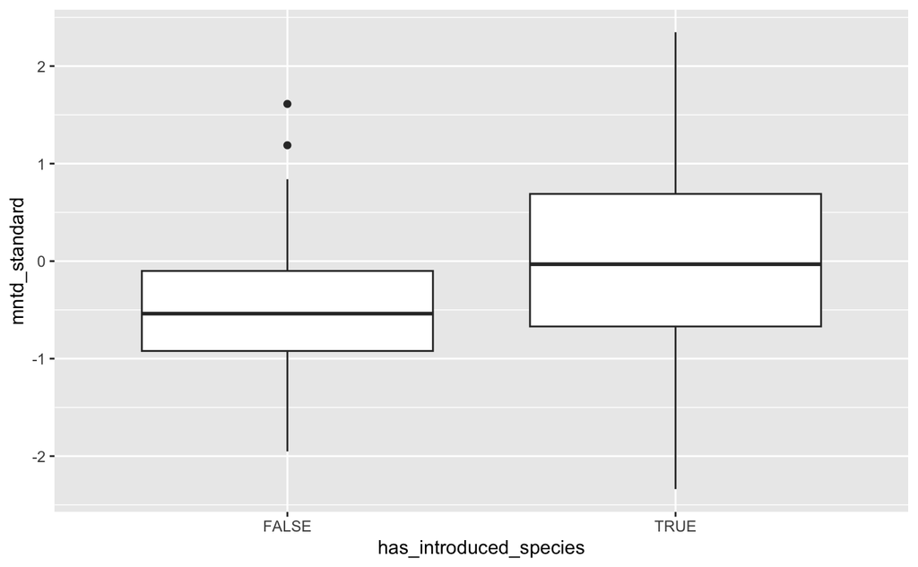

```r
ggplot(community_data_with_introductions, aes(x = has_introduced_species, y = mntd_standard)) + geom_boxplot()
```

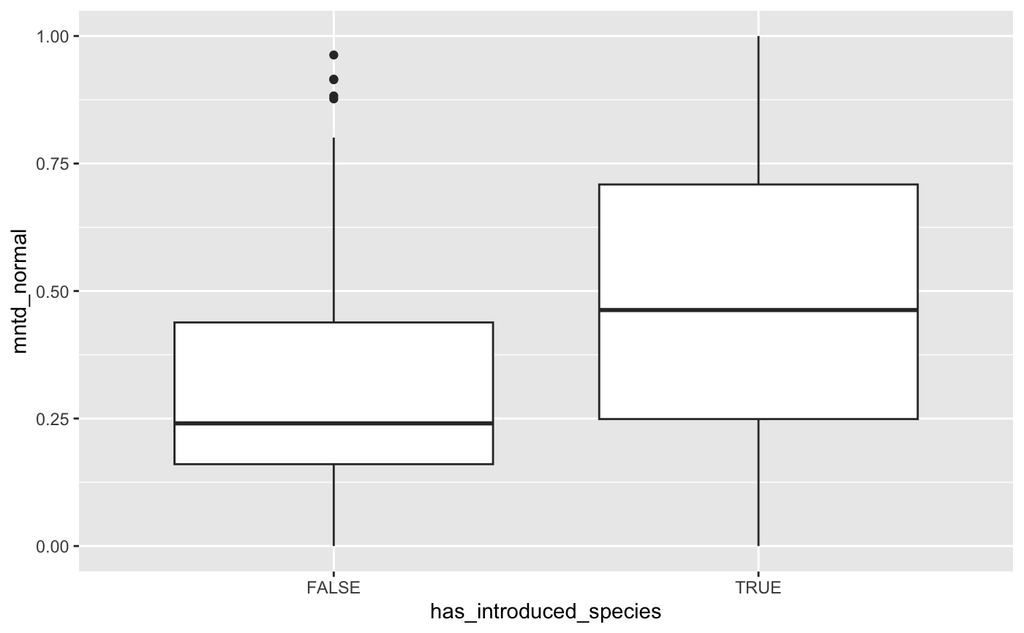

```r
ggplot(community_data_with_introductions, aes(x = has_introduced_species, y = mntd_normal)) + geom_boxplot()
```

```r
wilcox.test(mntd_standard ~ has_introduced_species, community_data_with_introductions, na.action = 'na.omit')
```

```
    Wilcoxon rank sum test with continuity correction

data:  mntd_standard by has_introduced_species
W = 7922, p-value = 0.00001262
alternative hypothesis: true location shift is not equal to 0
```

```r
wilcox.test(mntd_normal ~ has_introduced_species, community_data_with_introductions, na.action = 'na.omit')
```

```
    Wilcoxon rank sum test with continuity correction

data:  mntd_normal by has_introduced_species
W = 7376.5, p-value = 0.0000003705
alternative hypothesis: true location shift is not equal to 0
```

## Mass FDiv

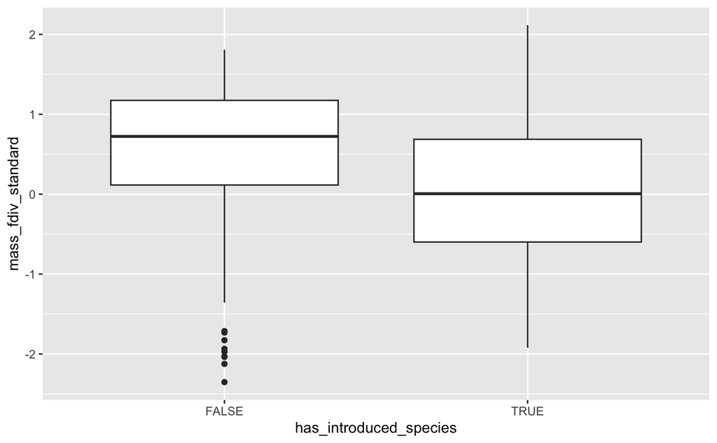

```r
ggplot(community_data_with_introductions, aes(x = has_introduced_species, y = mass_fdiv_standard)) + geom_boxplot()
```

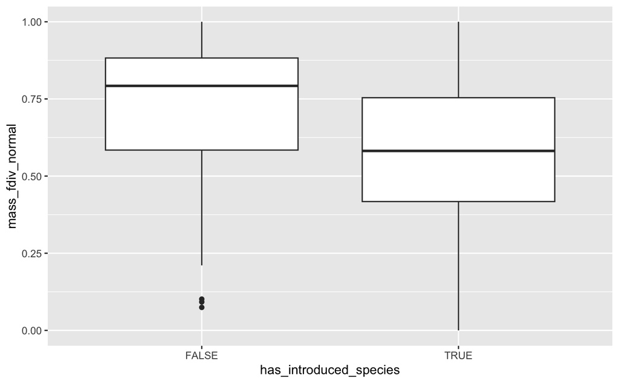

```r
ggplot(community_data_with_introductions, aes(x = has_introduced_species, y = mass_fdiv_normal)) + geom_boxplot()
```

```r
wilcox.test(mass_fdiv_standard ~ has_introduced_species, community_data_with_introductions, na.action = 'na.omit')
```

```
    Wilcoxon rank sum test with continuity correction

data:  mass_fdiv_standard by has_introduced_species
W = 15009, p-value = 0.0000007626
alternative hypothesis: true location shift is not equal to 0
```

There is a significant difference between the response of cities with introduced species (0.57±0.27) and those without (0.73±0.24) (p < 0.0001)

```r
wilcox.test(mass_fdiv_normal ~ has_introduced_species, community_data_with_introductions, na.action = 'na.omit')
```

```
    Wilcoxon rank sum test with continuity correction

data:  mass_fdiv_normal by has_introduced_species
W = 15204, p-value = 0.0000001989
alternative hypothesis: true location shift is not equal to 0
```

## Beak Gape FDiv

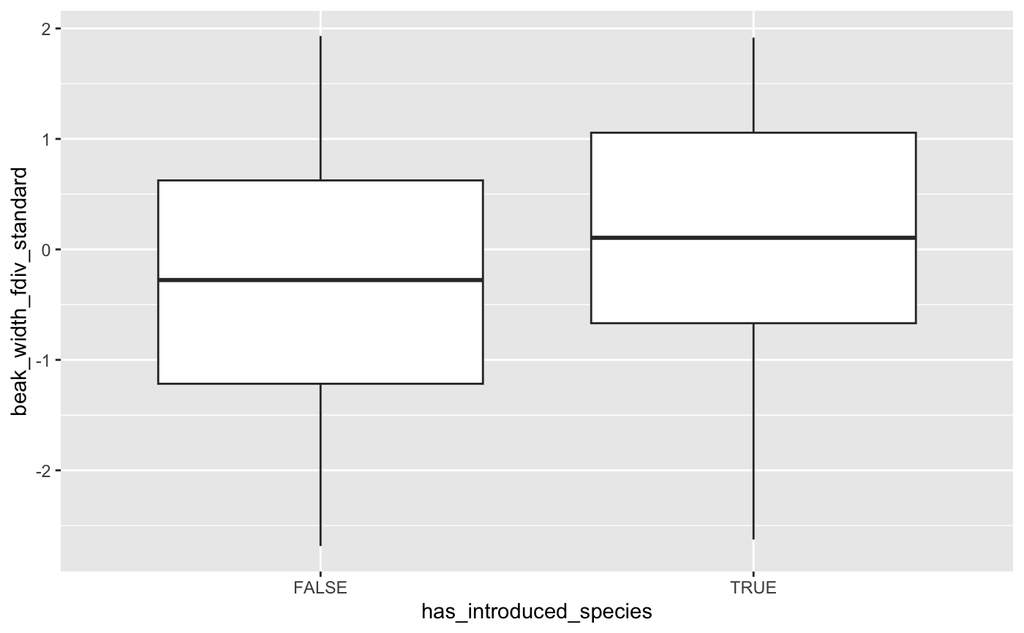

```r
ggplot(community_data_with_introductions, aes(x = has_introduced_species, y = beak_width_fdiv_standard)) + geom_boxplot()
```

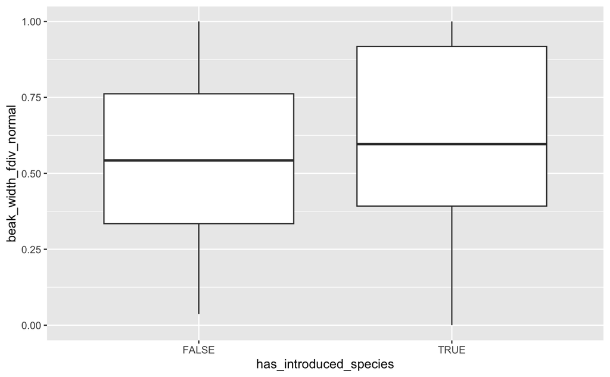

```r
ggplot(community_data_with_introductions, aes(x = has_introduced_species, y = beak_width_fdiv_normal)) + geom_boxplot()
```

```r
wilcox.test(beak_width_fdiv_standard ~ has_introduced_species, community_data_with_introductions, na.action = 'na.omit')
```

```
    Wilcoxon rank sum test with continuity correction

data:  beak_width_fdiv_standard by has_introduced_species
W = 8659, p-value = 0.0006786
alternative hypothesis: true location shift is not equal to 0
```

There is NOT a significant difference between the response of cities with introduced species (0.61±0.30) and those without (0.56±0.27)

```r
wilcox.test(beak_width_fdiv_normal ~ has_introduced_species, community_data_with_introductions, na.action = 'na.omit')
```

```
    Wilcoxon rank sum test with continuity correction

data:  beak_width_fdiv_normal by has_introduced_species
W = 9829.5, p-value = 0.06288
alternative hypothesis: true location shift is not equal to 0
```

## HWI FDiv

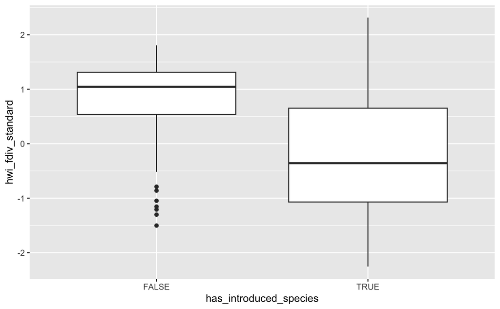

```r
ggplot(community_data_with_introductions, aes(x = has_introduced_species, y = hwi_fdiv_standard)) + geom_boxplot()
```

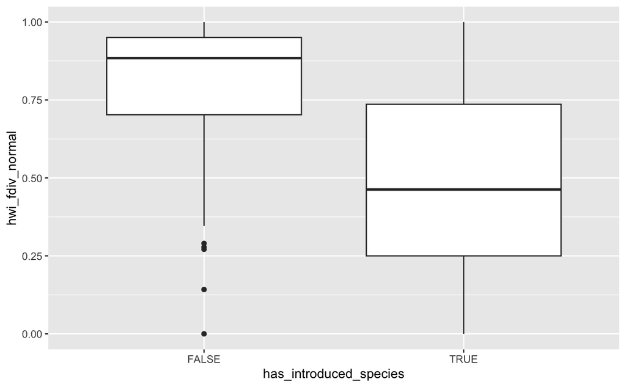

```r
ggplot(community_data_with_introductions, aes(x = has_introduced_species, y = hwi_fdiv_normal)) + geom_boxplot()
```

```r
wilcox.test(hwi_fdiv_standard ~ has_introduced_species, community_data_with_introductions, na.action = 'na.omit')
```

```
    Wilcoxon rank sum test with continuity correction

data:  hwi_fdiv_standard by has_introduced_species
W = 17622, p-value < 0.00000000000000022
alternative hypothesis: true location shift is not equal to 0
```

There is a significant difference between the response of cities with introduced species (0.49±0.30) and those without (0.79±0.21) (p < 0.0001)

```r
wilcox.test(hwi_fdiv_normal ~ has_introduced_species, community_data_with_introductions, na.action = 'na.omit')
```

```
    Wilcoxon rank sum test with continuity correction

data:  hwi_fdiv_normal by has_introduced_species
W = 17673, p-value < 0.00000000000000022
alternative hypothesis: true location shift is not equal to 0
```

## What proportion of cities in each realm have introduced species

```r
community_data_with_introductions %>% left_join(city_to_realm) %>%
  group_by(core_realm) %>%
  summarise(
    total_cities = n(),
    total_cities_with_introduced = sum(has_introduced_species),
    total_cities_without_introduced = n() - sum(has_introduced_species)) %>%
  arrange(core_realm)
```

| core_realm | total_cities | total_cities_with_introduced | total_cities_without_introduced |
| --- | --- | --- | --- |
| Afrotropic | 9 | 7 | 2 |
| Australasia | 6 | 6 | 0 |
| Indomalayan | 111 | 19 | 92 |
| Nearctic | 46 | 46 | 0 |
| Neotropic | 64 | 64 | 0 |
| Palearctic | 72 | 47 | 25 |

## Are any introduced species not also present in a city?

```r
communities %>%
  filter(origin == 'Introduced') %>%
  filter(relative_abundance_proxy < 0.1)
```

| city_id | city_name | ebird_species_name | seasonal | presence | origin | relative_abundance_proxy |
| --- | --- | --- | --- | --- | --- | --- |
| 501 | Bradenton | Streptopelia roseogrisea | Resident | Extant | Introduced | 0.00000000 |
| 502 | Tampa | Streptopelia roseogrisea | Resident | Extant | Introduced | 0.05395806 |
| 559 | Miami | Streptopelia roseogrisea | Resident | Extant | Introduced | 0.00000000 |
| 6601 | Bikaner | Spilopelia chinensis | Resident | Extant | Introduced | 0.00000000 |
| 13076 | Melbourne | Streptopelia roseogrisea | Resident | Extant | Introduced | 0.00000000 |

## What’s the average relative abundance of introduced species compared to native

```r
communities %>%
  group_by(origin) %>%
  summarise(average_relative_abundance = mean(relative_abundance_proxy))
```

| origin | average_relative_abundance |
| --- | --- |
| Introduced | 40.77328 |
| Native | 19.94619 |

```r
communities %>%
  group_by(origin) %>%
  filter(relative_abundance_proxy > 0) %>%
  summarise(average_relative_abundance = mean(relative_abundance_proxy))
```

| origin | average_relative_abundance |
| --- | --- |
| Introduced | 41.33181 |
| Native | 28.83069 |

```r
communities %>%
  group_by(origin) %>%
  summarise(average_relative_abundance = mean(relative_abundance_proxy))
```

| origin | average_relative_abundance |
| --- | --- |
| Introduced | 40.77328 |
| Native | 19.94619 |

# Create analysis data frame for modelling

```r
geography = read_csv(filename(CITY_DATA_OUTPUT_DIR, 'geography.csv'))
names(geography)
```

```
 [1] "city_id"                       "city_avg_ndvi"                 "city_avg_elevation"
 [4] "city_avg_temp"                 "city_avg_min_monthly_temp"     "city_avg_max_monthly_temp"
 [7] "city_avg_monthly_temp"         "city_avg_rainfall"             "city_avg_max_monthly_rainfall"
[10] "city_avg_min_monthly_rainfall" "city_avg_soil_moisture"        "city_max_elev"
[13] "city_min_elev"                 "city_elev_range"               "region_20km_avg_ndvi"
[16] "region_20km_avg_elevation"     "region_20km_avg_soil_moisture" "region_20km_max_elev"
[19] "region_20km_min_elev"          "region_20km_elev_range"        "region_50km_avg_ndvi"
[22] "region_50km_avg_elevation"     "region_50km_avg_soil_moisture" "region_50km_max_elev"
[25] "region_50km_min_elev"          "region_50km_elev_range"
```

```r
analysis_data = community_data_with_realm[,c('city_id',
       'mntd_standard', 'mass_fdiv_standard', 'beak_width_fdiv_standard', 'hwi_fdiv_standard',
       'mntd_normal', 'mass_fdiv_normal', 'beak_width_fdiv_normal', 'hwi_fdiv_normal',
       'core_realm')] %>%
  left_join(city_points[,c('city_id', 'latitude', 'longitude')]) %>%
  left_join(community_data_with_introductions[,c('city_id', 'has_introduced_species')]) %>%
  left_join(geography) %>%
  left_join(spatial_var)
analysis_data$abs_latitude = abs(analysis_data$latitude)
analysis_data$core_realm = factor(analysis_data$core_realm, levels = c('Palearctic', 'Nearctic', 'Neotropic', 'Afrotropic', 'Indomalayan', 'Australasia', 'Oceania'))
analysis_data$has_introduced_species = factor(analysis_data$has_introduced_species, level = c('FALSE', 'TRUE'), labels = c('No introduced species', 'Introduced species'))
```

```r
model_data = function(df, dependant_var) {
  df[,c(dependant_var, 'core_realm', 'abs_latitude', 'longitude', 'has_introduced_species', 'city_avg_ndvi', 'city_avg_elevation', 'city_avg_temp', 'city_avg_min_monthly_temp', 'city_avg_max_monthly_temp', 'city_avg_monthly_temp', 'city_avg_rainfall', 'city_avg_max_monthly_rainfall', 'city_avg_min_monthly_rainfall', 'city_avg_soil_moisture', 'city_max_elev', 'city_min_elev', 'city_elev_range', 'region_20km_avg_ndvi', 'region_20km_avg_elevation', 'region_20km_avg_soil_moisture', 'region_20km_max_elev', 'region_20km_min_elev', 'region_20km_elev_range', 'region_50km_avg_ndvi', 'region_50km_avg_elevation', 'region_50km_avg_soil_moisture', 'region_50km_max_elev', 'region_50km_min_elev', 'region_50km_elev_range')]
}
model_data(analysis_data, 'mntd_standard')
```

| mntd_standard | core_realm | abs_latitude | longitude | has_introduced_species | city_avg_ndvi | city_avg_elevation | city_avg_temp | city_avg_min_monthly_temp | city_avg_max_monthly_temp | city_avg_monthly_temp | city_avg_rainfall | city_avg_max_monthly_rainfall | city_avg_min_monthly_rainfall | city_avg_soil_moisture | city_max_elev | city_min_elev | city_elev_range | region_20km_avg_ndvi | region_20km_avg_elevation | region_20km_avg_soil_moisture | region_20km_max_elev | region_20km_min_elev | region_20km_elev_range | region_50km_avg_ndvi | region_50km_avg_elevation | region_50km_avg_soil_moisture | region_50km_max_elev | region_50km_min_elev | region_50km_elev_range |
| --- | --- | --- | --- | --- | --- | --- | --- | --- | --- | --- | --- | --- | --- | --- | --- | --- | --- | --- | --- | --- | --- | --- | --- | --- | --- | --- | --- | --- | --- |
| -0.084389453 | Nearctic | 122.1452910 | 37.5690821 | Introduced species | 3113.6987 | 111.26014864 | 146.24866 | 252.8555 | 48.7262506 | 204.12926 | 493.686057 | 104.606835 | 1.03873425386 | 0.21549465 | 805 | -10 | 815 | 5454.6691 | 210.8905737 | 0.21287145 | 855 | -15 | 870 | 5115.4191 | 140.4292828 | 0.21068845 | 855 | -987 | 1842 |
| -1.076197862 | Nearctic | 117.9546731 | 33.9537128 | Introduced species | 2897.6886 | 235.16841327 | 176.46005 | 305.8411 | 61.5241086 | 244.31704 | 362.670410 | 76.408069 | 0.91740449236 | 0.12370221 | 1195 | -383 | 1578 | 4594.1479 | 528.0138882 | 0.11877971 | 2585 | -610 | 3195 | 3896.6900 | 470.7197792 | 0.11372071 | 2585 | -1153 | 3738 |
| 1.637779894 | Nearctic | 122.0494836 | 37.9148906 | Introduced species | 3851.3088 | 165.75496950 | 147.99123 | 275.5662 | 37.7367961 | 237.82942 | 501.897078 | 108.171241 | 1.00000000000 | 0.25915956 | 446 | -10 | 456 | 4358.6075 | 158.8756065 | 0.23426905 | 805 | -10 | 815 | 4710.9952 | 156.2128509 | 0.21611613 | 855 | -10 | 865 |
| -0.907739642 | Nearctic | 117.1117202 | 32.8218859 | Introduced species | 2957.3080 | 186.83724710 | 170.49751 | 276.2381 | 67.5125315 | 208.72557 | 284.600929 | 56.802968 | 1.06499393567 | 0.13712230 | 490 | -206 | 696 | 4198.3546 | 194.3923050 | 0.11527433 | 1298 | -849 | 2147 | 4281.5152 | 193.4678718 | 0.11300305 | 1636 | -1565 | 3201 |
| 0.184087715 | Nearctic | 119.0454391 | 35.3659411 | Introduced species | 2636.5114 | 167.10991576 | 185.10665 | 371.5248 | 30.6542433 | 340.87060 | 168.907805 | 31.026437 | 0.00000000000 | 0.08722396 | 356 | 109 | 247 | 3888.1956 | 314.5684893 | 0.09672757 | 1608 | 89 | 1519 | 4040.1960 | 620.5593666 | 0.10980902 | 2195 | 69 | 2126 |
| 1.323878866 | Nearctic | 119.7712385 | 36.7872542 | Introduced species | 2964.4562 | 108.25231677 | 168.92998 | 366.8994 | 23.8819509 | 343.01750 | 286.919154 | 54.227069 | 0.00000000000 | 0.12471541 | 169 | 86 | 83 | 4282.3225 | 153.6230567 | 0.11668160 | 733 | 67 | 666 | 4434.5790 | 335.1654842 | 0.13689222 | 2438 | 47 | 2391 |
| 1.521700458 | Nearctic | 121.3870085 | 38.6040618 | Introduced species | 3565.9381 | 44.93971202 | 161.12237 | 341.0807 | 33.1656835 | 307.91501 | 479.818962 | 105.345884 | 1.00000000000 | 0.18338941 | 172 | 2 | 170 | 4563.4043 | 102.5788929 | 0.19735243 | 627 | 0 | 627 | 4916.5332 | 216.8792943 | 0.19913815 | 1387 | -10 | 1397 |
| -0.939562413 | Nearctic | 115.4476865 | 32.6254534 | Introduced species | 1313.7957 | 12.40880504 | 224.79959 | 419.7165 | 43.9023338 | 375.81419 | 82.277016 | 12.993751 | 0.00000000000 | 0.07847880 | 24 | 0 | 24 | 2640.1127 | 32.1143094 | 0.07687504 | 549 | -55 | 604 | 2231.3882 | 68.9115982 | 0.06793060 | 1449 | -114 | 1563 |
| -0.648996168 | Nearctic | 110.9752075 | 29.0858350 | Introduced species | 1707.6338 | 229.60534756 | 240.64586 | 388.3613 | 82.7436196 | 305.61772 | 284.620370 | 85.484481 | 2.14971659851 | 0.08488590 | 413 | 210 | 203 | 2881.2644 | 281.9873982 | 0.08036667 | 609 | 136 | 473 | 2895.5948 | 327.1727296 | 0.08913616 | 645 | 75 | 570 |
| 0.684891887 | Neotropic | 107.4071919 | 24.7966191 | Introduced species | 2700.7957 | 148.11599241 | 253.03355 | 364.9872 | 111.6540431 | 253.33316 | 643.840672 | 201.882962 | 1.85974834444 | 0.21338037 | 225 | 35 | 190 | 4836.6968 | 170.0630282 | 0.19178469 | 700 | 10 | 690 | 4950.5495 | 288.0626439 | 0.17184282 | 1350 | -80 | 1430 |

[output cut: 298 more lines]

```r
model_data(analysis_data, 'mntd_normal')
```

| mntd_normal | core_realm | abs_latitude | longitude | has_introduced_species | city_avg_ndvi | city_avg_elevation | city_avg_temp | city_avg_min_monthly_temp | city_avg_max_monthly_temp | city_avg_monthly_temp | city_avg_rainfall | city_avg_max_monthly_rainfall | city_avg_min_monthly_rainfall | city_avg_soil_moisture | city_max_elev | city_min_elev | city_elev_range | region_20km_avg_ndvi | region_20km_avg_elevation | region_20km_avg_soil_moisture | region_20km_max_elev | region_20km_min_elev | region_20km_elev_range | region_50km_avg_ndvi | region_50km_avg_elevation | region_50km_avg_soil_moisture | region_50km_max_elev | region_50km_min_elev | region_50km_elev_range |
| --- | --- | --- | --- | --- | --- | --- | --- | --- | --- | --- | --- | --- | --- | --- | --- | --- | --- | --- | --- | --- | --- | --- | --- | --- | --- | --- | --- | --- | --- |
| 0.4659133138381907 | Nearctic | 122.1452910 | 37.5690821 | Introduced species | 3113.6987 | 111.26014864 | 146.24866 | 252.8555 | 48.7262506 | 204.12926 | 493.686057 | 104.606835 | 1.03873425386 | 0.21549465 | 805 | -10 | 815 | 5454.6691 | 210.8905737 | 0.21287145 | 855 | -15 | 870 | 5115.4191 | 140.4292828 | 0.21068845 | 855 | -987 | 1842 |
| 0.0036782646866787 | Nearctic | 117.9546731 | 33.9537128 | Introduced species | 2897.6886 | 235.16841327 | 176.46005 | 305.8411 | 61.5241086 | 244.31704 | 362.670410 | 76.408069 | 0.91740449236 | 0.12370221 | 1195 | -383 | 1578 | 4594.1479 | 528.0138882 | 0.11877971 | 2585 | -610 | 3195 | 3896.6900 | 470.7197792 | 0.11372071 | 2585 | -1153 | 3738 |
| 0.9960546075451990 | Nearctic | 122.0494836 | 37.9148906 | Introduced species | 3851.3088 | 165.75496950 | 147.99123 | 275.5662 | 37.7367961 | 237.82942 | 501.897078 | 108.171241 | 1.00000000000 | 0.25915956 | 446 | -10 | 456 | 4358.6075 | 158.8756065 | 0.23426905 | 805 | -10 | 815 | 4710.9952 | 156.2128509 | 0.21611613 | 855 | -10 | 865 |
| 0.0007161844614168 | Nearctic | 117.1117202 | 32.8218859 | Introduced species | 2957.3080 | 186.83724710 | 170.49751 | 276.2381 | 67.5125315 | 208.72557 | 284.600929 | 56.802968 | 1.06499393567 | 0.13712230 | 490 | -206 | 696 | 4198.3546 | 194.3923050 | 0.11527433 | 1298 | -849 | 2147 | 4281.5152 | 193.4678718 | 0.11300305 | 1636 | -1565 | 3201 |
| 0.5922945937217381 | Nearctic | 119.0454391 | 35.3659411 | Introduced species | 2636.5114 | 167.10991576 | 185.10665 | 371.5248 | 30.6542433 | 340.87060 | 168.907805 | 31.026437 | 0.00000000000 | 0.08722396 | 356 | 109 | 247 | 3888.1956 | 314.5684893 | 0.09672757 | 1608 | 89 | 1519 | 4040.1960 | 620.5593666 | 0.10980902 | 2195 | 69 | 2126 |
| 0.9922388334720152 | Nearctic | 119.7712385 | 36.7872542 | Introduced species | 2964.4562 | 108.25231677 | 168.92998 | 366.8994 | 23.8819509 | 343.01750 | 286.919154 | 54.227069 | 0.00000000000 | 0.12471541 | 169 | 86 | 83 | 4282.3225 | 153.6230567 | 0.11668160 | 733 | 67 | 666 | 4434.5790 | 335.1654842 | 0.13689222 | 2438 | 47 | 2391 |
| 0.9941331553051580 | Nearctic | 121.3870085 | 38.6040618 | Introduced species | 3565.9381 | 44.93971202 | 161.12237 | 341.0807 | 33.1656835 | 307.91501 | 479.818962 | 105.345884 | 1.00000000000 | 0.18338941 | 172 | 2 | 170 | 4563.4043 | 102.5788929 | 0.19735243 | 627 | 0 | 627 | 4916.5332 | 216.8792943 | 0.19913815 | 1387 | -10 | 1397 |
| 0.0684659823586751 | Nearctic | 115.4476865 | 32.6254534 | Introduced species | 1313.7957 | 12.40880504 | 224.79959 | 419.7165 | 43.9023338 | 375.81419 | 82.277016 | 12.993751 | 0.00000000000 | 0.07847880 | 24 | 0 | 24 | 2640.1127 | 32.1143094 | 0.07687504 | 549 | -55 | 604 | 2231.3882 | 68.9115982 | 0.06793060 | 1449 | -114 | 1563 |
| 0.2059497986580262 | Nearctic | 110.9752075 | 29.0858350 | Introduced species | 1707.6338 | 229.60534756 | 240.64586 | 388.3613 | 82.7436196 | 305.61772 | 284.620370 | 85.484481 | 2.14971659851 | 0.08488590 | 413 | 210 | 203 | 2881.2644 | 281.9873982 | 0.08036667 | 609 | 136 | 473 | 2895.5948 | 327.1727296 | 0.08913616 | 645 | 75 | 570 |
| 0.6506136477281480 | Neotropic | 107.4071919 | 24.7966191 | Introduced species | 2700.7957 | 148.11599241 | 253.03355 | 364.9872 | 111.6540431 | 253.33316 | 643.840672 | 201.882962 | 1.85974834444 | 0.21338037 | 225 | 35 | 190 | 4836.6968 | 170.0630282 | 0.19178469 | 700 | 10 | 690 | 4950.5495 | 288.0626439 | 0.17184282 | 1350 | -80 | 1430 |

[output cut: 298 more lines]

```r
names(analysis_data)
```

```
 [1] "city_id"                       "mntd_standard"                 "mass_fdiv_standard"
 [4] "beak_width_fdiv_standard"      "hwi_fdiv_standard"             "mntd_normal"
 [7] "mass_fdiv_normal"              "beak_width_fdiv_normal"        "hwi_fdiv_normal"
[10] "core_realm"                    "latitude"                      "longitude"
[13] "geometry"                      "has_introduced_species"        "city_avg_ndvi"
[16] "city_avg_elevation"            "city_avg_temp"                 "city_avg_min_monthly_temp"
[19] "city_avg_max_monthly_temp"     "city_avg_monthly_temp"         "city_avg_rainfall"
[22] "city_avg_max_monthly_rainfall" "city_avg_min_monthly_rainfall" "city_avg_soil_moisture"
[25] "city_max_elev"                 "city_min_elev"                 "city_elev_range"
[28] "region_20km_avg_ndvi"          "region_20km_avg_elevation"     "region_20km_avg_soil_moisture"
[31] "region_20km_max_elev"          "region_20km_min_elev"          "region_20km_elev_range"
[34] "region_50km_avg_ndvi"          "region_50km_avg_elevation"     "region_50km_avg_soil_moisture"
[37] "region_50km_max_elev"          "region_50km_min_elev"          "region_50km_elev_range"
[40] "NMDS1"                         "NMDS2"                         "abs_latitude"
```

## NMDS Spatial Helpers

```r
analysis_data_nmds_coords = analysis_data[,c('NMDS1', 'NMDS2')]
coordinates(analysis_data_nmds_coords)  = ~ NMDS1 + NMDS2

analysis_data_nmds_nearneigh <- knearneigh(analysis_data_nmds_coords)
analysis_data_nmds_neighbours <- knn2nb(analysis_data_nmds_nearneigh)
```

### Polygons around realms in NMDS plot

```r
cities_to_realms_nmds = read_csv(filename(CITY_DATA_OUTPUT_DIR, 'realms.csv')) %>% left_join(analysis_data) %>% filter(!is.na(NMDS1))
unique(cities_to_realms_nmds$core_realm)
```

```
[1] "Nearctic"    "Neotropic"   "Palearctic"  "Afrotropic"  "Indomalayan" "Australasia"
```

```r
realm_nmds_neartic_polygon = cities_to_realms_nmds %>% filter(core_realm == 'Nearctic') %>% slice(chull(NMDS1, NMDS2))
realm_nmds_neotropic_polygon = cities_to_realms_nmds %>% filter(core_realm == 'Neotropic') %>% slice(chull(NMDS1, NMDS2))
realm_nmds_palearctic_polygon = cities_to_realms_nmds %>% filter(core_realm == 'Palearctic') %>% slice(chull(NMDS1, NMDS2))
realm_nmds_afrotropic_polygon = cities_to_realms_nmds %>% filter(core_realm == 'Afrotropic') %>% slice(chull(NMDS1, NMDS2))
realm_nmds_indomalayan_polygon = cities_to_realms_nmds %>% filter(core_realm == 'Indomalayan') %>% slice(chull(NMDS1, NMDS2))
realm_nmds_australasia_polygon = cities_to_realms_nmds %>% filter(core_realm == 'Australasia') %>% slice(chull(NMDS1, NMDS2))

polygon_line_type = 'dashed'
polygon_linewidth = 0.4

with_realms_nmds = function(g) {
  g +
    geom_polygon(data = realm_nmds_neartic_polygon, linewidth = polygon_linewidth, linetype = polygon_line_type, alpha = 0) +
    geom_polygon(data = realm_nmds_neotropic_polygon, linewidth = polygon_linewidth, linetype = polygon_line_type, alpha = 0) +
    geom_polygon(data = realm_nmds_palearctic_polygon, linewidth = polygon_linewidth, linetype = polygon_line_type, alpha = 0) +
    geom_polygon(data = realm_nmds_afrotropic_polygon, linewidth = polygon_linewidth, linetype = polygon_line_type, alpha = 0) +
    geom_polygon(data = realm_nmds_indomalayan_polygon, linewidth = polygon_linewidth, linetype = polygon_line_type, alpha = 0) +
    geom_polygon(data = realm_nmds_australasia_polygon, linewidth = polygon_linewidth, linetype = polygon_line_type, alpha = 0)
}
```

## Lat Long Spatial Helpers

```r
analysis_data_latlong_coords = analysis_data[,c('longitude', 'latitude')]
coordinates(analysis_data_latlong_coords)  = ~ longitude + latitude

analysis_data_coords_nearneigh <- knearneigh(analysis_data_latlong_coords, longlat = TRUE)
analysis_data_neighbours <- knn2nb(analysis_data_coords_nearneigh)
```

### Polygons around realms in lat long plot

```r
cities_to_realms_latlong = read_csv(filename(CITY_DATA_OUTPUT_DIR, 'realms.csv')) %>% left_join(analysis_data) %>% filter(!is.na(latitude))
unique(cities_to_realms_latlong$core_realm)
```

```
[1] "Nearctic"    "Neotropic"   "Palearctic"  "Afrotropic"  "Indomalayan" "Australasia"
```

```r
realm_latlong_neartic_polygon = cities_to_realms_latlong %>% filter(core_realm == 'Nearctic') %>% slice(chull(latitude, longitude))
realm_latlong_neotropic_polygon = cities_to_realms_latlong %>% filter(core_realm == 'Neotropic') %>% slice(chull(latitude, longitude))
realm_latlong_palearctic_polygon = cities_to_realms_latlong %>% filter(core_realm == 'Palearctic') %>% slice(chull(latitude, longitude))
realm_latlong_afrotropic_polygon = cities_to_realms_latlong %>% filter(core_realm == 'Afrotropic') %>% slice(chull(latitude, longitude))
realm_latlong_indomalayan_polygon = cities_to_realms_latlong %>% filter(core_realm == 'Indomalayan') %>% slice(chull(latitude, longitude))
realm_latlong_australasia_polygon = cities_to_realms_latlong %>% filter(core_realm == 'Australasia') %>% slice(chull(latitude, longitude))

with_realms_latlong = function(g) {
  g +
    geom_polygon(data = realm_latlong_neartic_polygon, linewidth = polygon_linewidth, linetype = polygon_line_type, alpha = 0) +
    geom_polygon(data = realm_latlong_neotropic_polygon, linewidth = polygon_linewidth, linetype = polygon_line_type, alpha = 0) +
    geom_polygon(data = realm_latlong_palearctic_polygon, linewidth = polygon_linewidth, linetype = polygon_line_type, alpha = 0) +
    geom_polygon(data = realm_latlong_afrotropic_polygon, linewidth = polygon_linewidth, linetype = polygon_line_type, alpha = 0) +
    geom_polygon(data = realm_latlong_indomalayan_polygon, linewidth = polygon_linewidth, linetype = polygon_line_type, alpha = 0) +
    geom_polygon(data = realm_latlong_australasia_polygon, linewidth = polygon_linewidth, linetype = polygon_line_type, alpha = 0)
}
```

# Check for spatial autocorrelation

## MNTD

### Lat/Long

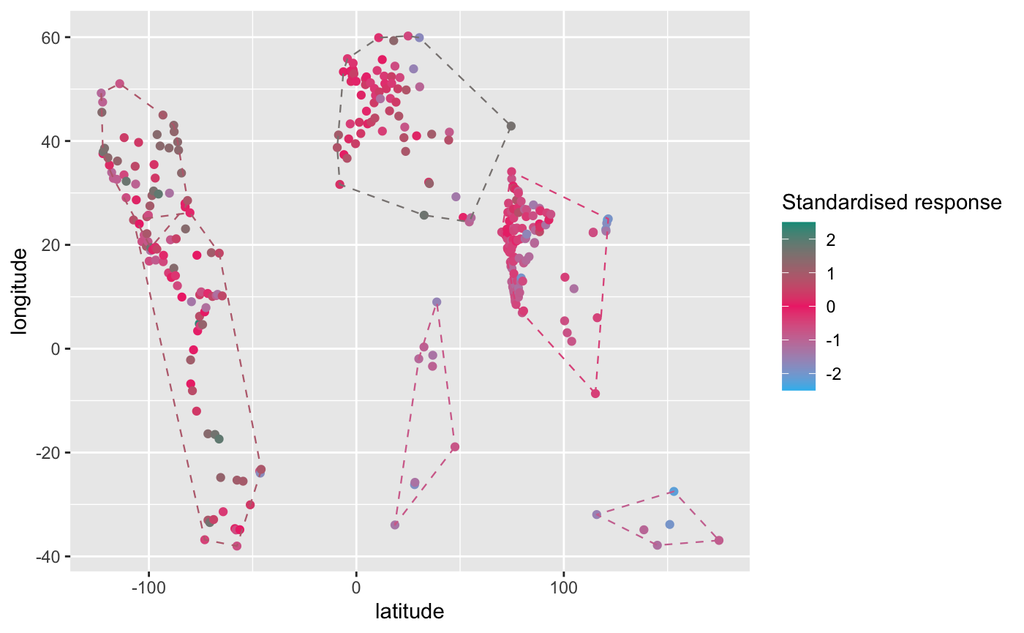

```r
with_realms_latlong(ggplot(analysis_data, aes(x = latitude, y = longitude, colour = mntd_standard)) + geom_point() + standardised_colours_scale + labs(colour = "Standardised response"))
```

```r
moran.test(analysis_data$mntd_standard, nb2listw(analysis_data_neighbours))
```

```
    Moran I test under randomisation

data:  analysis_data$mntd_standard
weights: nb2listw(analysis_data_neighbours)

Moran I statistic standard deviate = 7.343, p-value = 0.0000000000001044
alternative hypothesis: greater
sample estimates:
Moran I statistic       Expectation          Variance
      0.529792986      -0.003257329       0.005269694
```

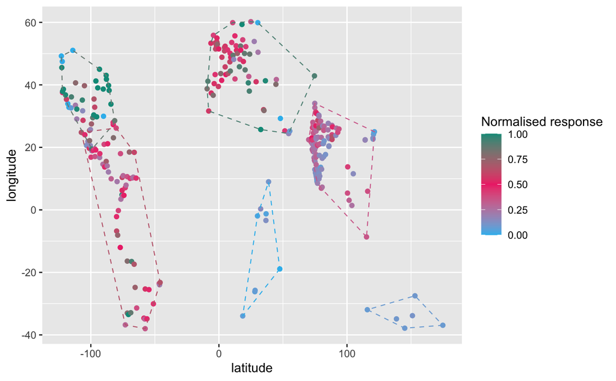

```r
with_realms_latlong(ggplot(analysis_data, aes(x = latitude, y = longitude, colour = mntd_normal)) + geom_point() + normalised_colours_scale + labs(colour = "Normalised response"))
```

```r
moran.test(analysis_data$mntd_normal, nb2listw(analysis_data_neighbours))
```

```
    Moran I test under randomisation

data:  analysis_data$mntd_normal
weights: nb2listw(analysis_data_neighbours)

Moran I statistic standard deviate = 7.6496, p-value = 0.00000000000001008
alternative hypothesis: greater
sample estimates:
Moran I statistic       Expectation          Variance
      0.552360477      -0.003257329       0.005275586
```

### NMDS

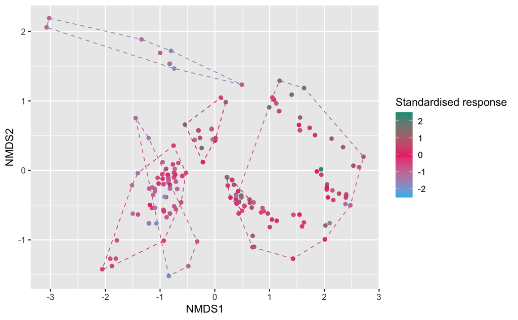

```r
with_realms_nmds(ggplot(analysis_data, aes(x = NMDS1, y = NMDS2, colour = mntd_standard)) + geom_point() + standardised_colours_scale + labs(colour = "Standardised response"))
```

```r
moran.test(analysis_data$mntd_standard, nb2listw(analysis_data_nmds_neighbours))
```

```
    Moran I test under randomisation

data:  analysis_data$mntd_standard
weights: nb2listw(analysis_data_nmds_neighbours)

Moran I statistic standard deviate = 6.5193, p-value = 0.00000000003531
alternative hypothesis: greater
sample estimates:
Moran I statistic       Expectation          Variance
      0.445538119      -0.003257329       0.004739028
```

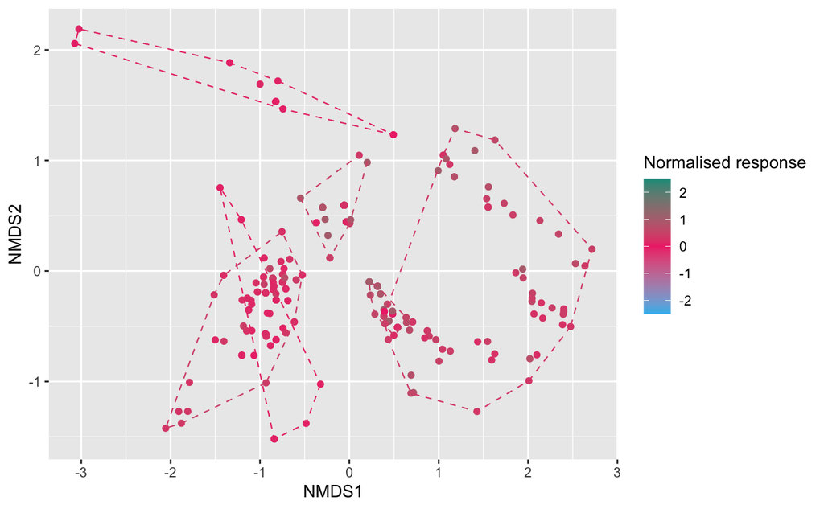

```r
with_realms_nmds(ggplot(analysis_data, aes(x = NMDS1, y = NMDS2, colour = mntd_normal)) + geom_point() + standardised_colours_scale + labs(colour = "Normalised response"))
```

```r
moran.test(analysis_data$mntd_normal, nb2listw(analysis_data_nmds_neighbours))
```

```
    Moran I test under randomisation

data:  analysis_data$mntd_normal
weights: nb2listw(analysis_data_nmds_neighbours)

Moran I statistic standard deviate = 6.2392, p-value = 0.0000000002199
alternative hypothesis: greater
sample estimates:
Moran I statistic       Expectation          Variance
      0.426489674      -0.003257329       0.004744227
```

## FDiv Beak Width

### Lat/Long

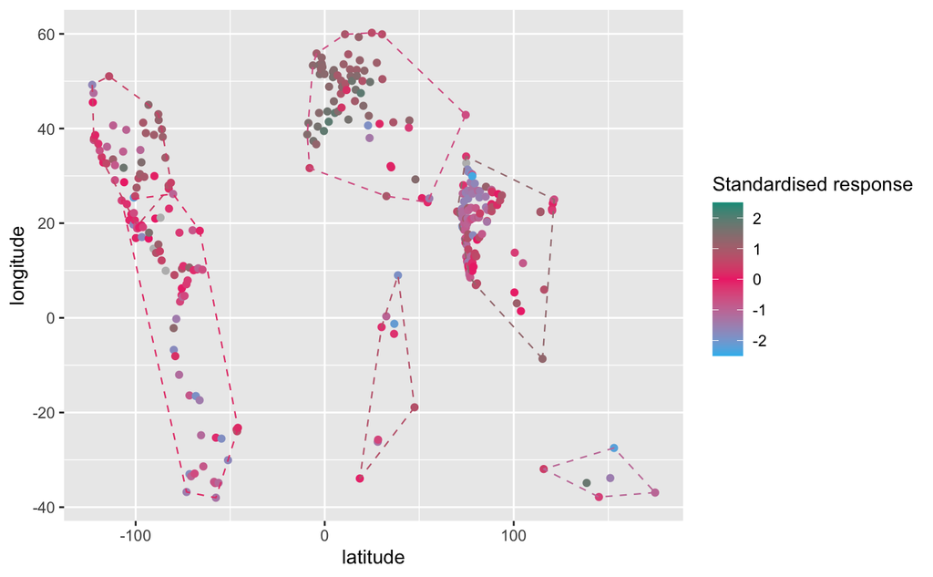

```r
with_realms_latlong(ggplot(analysis_data, aes(x = latitude, y = longitude, colour = beak_width_fdiv_standard)) + geom_point() + standardised_colours_scale + labs(colour = "Standardised response"))
```

```r
moran.test(analysis_data$beak_width_fdiv_standard, nb2listw(analysis_data_neighbours))
```

```
    Moran I test under randomisation

data:  analysis_data$beak_width_fdiv_standard
weights: nb2listw(analysis_data_neighbours)

Moran I statistic standard deviate = 7.7208, p-value = 0.000000000000005781
alternative hypothesis: greater
sample estimates:
Moran I statistic       Expectation          Variance
      0.557818587      -0.003257329       0.005281064
```

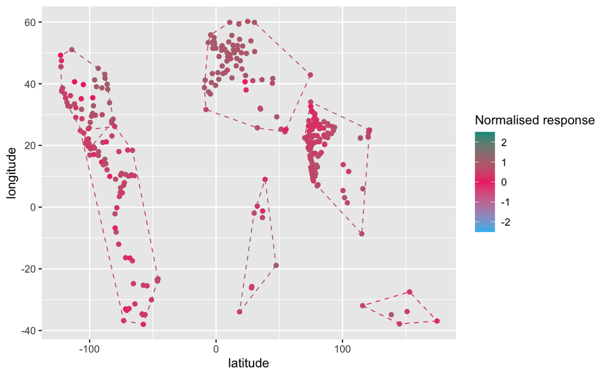

```r
with_realms_latlong(ggplot(analysis_data, aes(x = latitude, y = longitude, colour = beak_width_fdiv_normal)) + geom_point() + standardised_colours_scale + labs(colour = "Normalised response"))
```

```r
moran.test(analysis_data$beak_width_fdiv_normal, nb2listw(analysis_data_neighbours))
```

```
    Moran I test under randomisation

data:  analysis_data$beak_width_fdiv_normal
weights: nb2listw(analysis_data_neighbours)

Moran I statistic standard deviate = 8.3245, p-value < 0.00000000000000022
alternative hypothesis: greater
sample estimates:
Moran I statistic       Expectation          Variance
      0.601742587      -0.003257329       0.005281967
```

### NMDS

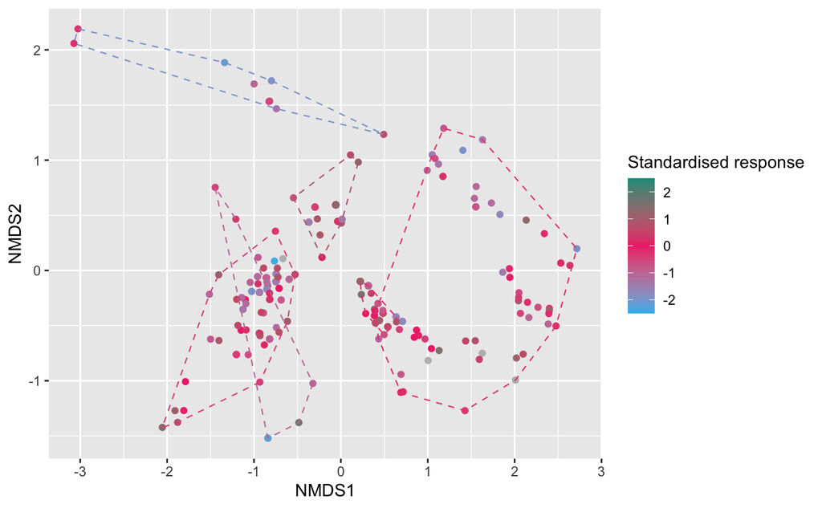

```r
with_realms_nmds(ggplot(analysis_data, aes(x = NMDS1, y = NMDS2, colour = beak_width_fdiv_standard)) + geom_point() + standardised_colours_scale + labs(colour = "Standardised response"))
```

```r
moran.test(analysis_data$beak_width_fdiv_standard, nb2listw(analysis_data_nmds_neighbours))
```

```
    Moran I test under randomisation

data:  analysis_data$beak_width_fdiv_standard
weights: nb2listw(analysis_data_nmds_neighbours)

Moran I statistic standard deviate = 8.0587, p-value = 0.0000000000000003855
alternative hypothesis: greater
sample estimates:
Moran I statistic       Expectation          Variance
      0.552096148      -0.003257329       0.004749061
```

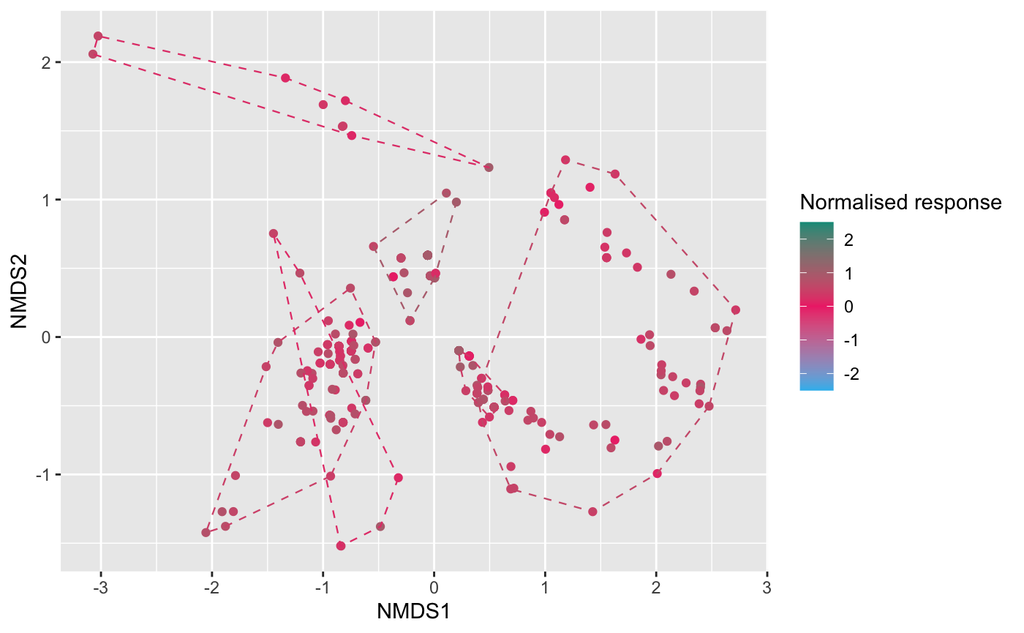

```r
with_realms_nmds(ggplot(analysis_data, aes(x = NMDS1, y = NMDS2, colour = beak_width_fdiv_normal)) + geom_point() + standardised_colours_scale + labs(colour = "Normalised response"))
```

```r
moran.test(analysis_data$beak_width_fdiv_normal, nb2listw(analysis_data_nmds_neighbours))
```

```
    Moran I test under randomisation

data:  analysis_data$beak_width_fdiv_normal
weights: nb2listw(analysis_data_nmds_neighbours)

Moran I statistic standard deviate = 7.5255, p-value = 0.00000000000002625
alternative hypothesis: greater
sample estimates:
Moran I statistic       Expectation          Variance
      0.515397518      -0.003257329       0.004749858
```

## FDiv HWI

### Lat/Long

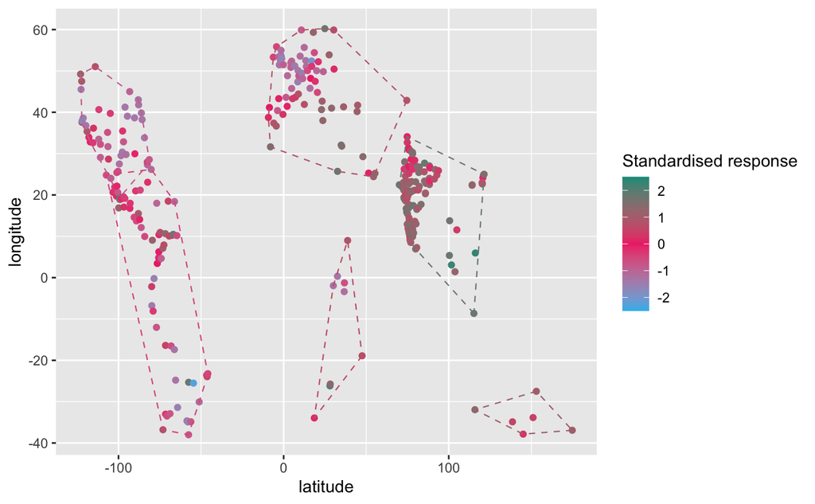

```r
with_realms_latlong(ggplot(analysis_data, aes(x = latitude, y = longitude, colour = hwi_fdiv_standard)) + geom_point() + standardised_colours_scale + labs(colour = "Standardised response"))
```

```r
moran.test(analysis_data$hwi_fdiv_standard, nb2listw(analysis_data_neighbours))
```

```
    Moran I test under randomisation

data:  analysis_data$hwi_fdiv_standard
weights: nb2listw(analysis_data_neighbours)

Moran I statistic standard deviate = 9.756, p-value < 0.00000000000000022
alternative hypothesis: greater
sample estimates:
Moran I statistic       Expectation          Variance
      0.705943030      -0.003257329       0.005284408
```

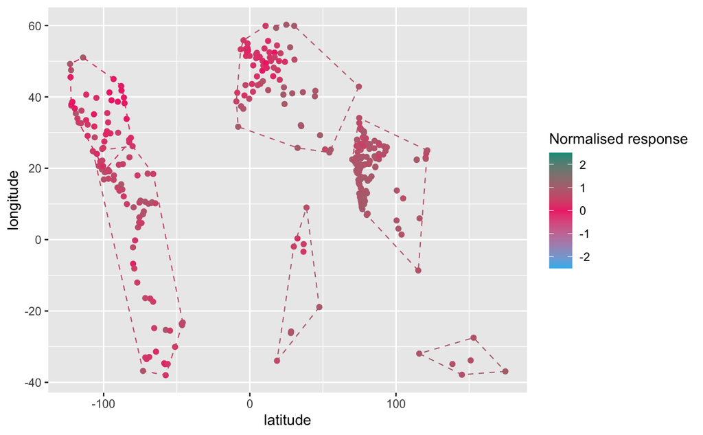

```r
with_realms_latlong(ggplot(analysis_data, aes(x = latitude, y = longitude, colour = hwi_fdiv_normal)) + geom_point() + standardised_colours_scale + labs(colour = "Normalised response"))
```

```r
moran.test(analysis_data$hwi_fdiv_normal, nb2listw(analysis_data_neighbours))
```

```
    Moran I test under randomisation

data:  analysis_data$hwi_fdiv_normal
weights: nb2listw(analysis_data_neighbours)

Moran I statistic standard deviate = 10.186, p-value < 0.00000000000000022
alternative hypothesis: greater
sample estimates:
Moran I statistic       Expectation          Variance
      0.737118550      -0.003257329       0.005283050
```

### NMDS

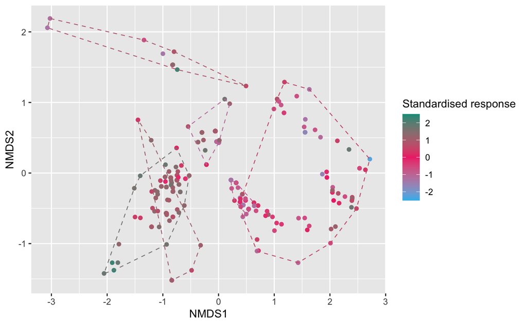

```r
with_realms_nmds(ggplot(analysis_data, aes(x = NMDS1, y = NMDS2, colour = hwi_fdiv_standard)) + geom_point() + standardised_colours_scale + labs(colour = "Standardised response"))
```

```r
moran.test(analysis_data$hwi_fdiv_standard, nb2listw(analysis_data_nmds_neighbours))
```

```
    Moran I test under randomisation

data:  analysis_data$hwi_fdiv_standard
weights: nb2listw(analysis_data_nmds_neighbours)

Moran I statistic standard deviate = 5.7294, p-value = 0.000000005039
alternative hypothesis: greater
sample estimates:
Moran I statistic       Expectation          Variance
      0.391697713      -0.003257329       0.004752012
```

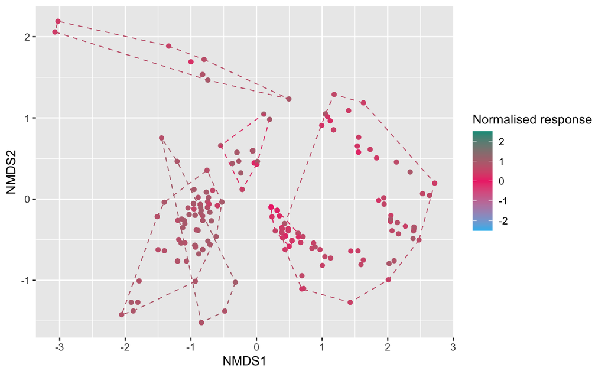

```r
with_realms_nmds(ggplot(analysis_data, aes(x = NMDS1, y = NMDS2, colour = hwi_fdiv_normal)) + geom_point() + standardised_colours_scale + labs(colour = "Normalised response"))
```

```r
moran.test(analysis_data$hwi_fdiv_normal, nb2listw(analysis_data_nmds_neighbours))
```

```
    Moran I test under randomisation

data:  analysis_data$hwi_fdiv_normal
weights: nb2listw(analysis_data_nmds_neighbours)

Moran I statistic standard deviate = 6.2803, p-value = 0.0000000001689
alternative hypothesis: greater
sample estimates:
Moran I statistic       Expectation          Variance
      0.429622019      -0.003257329       0.004750814
```

## FDiv Mass

### Lat/Long

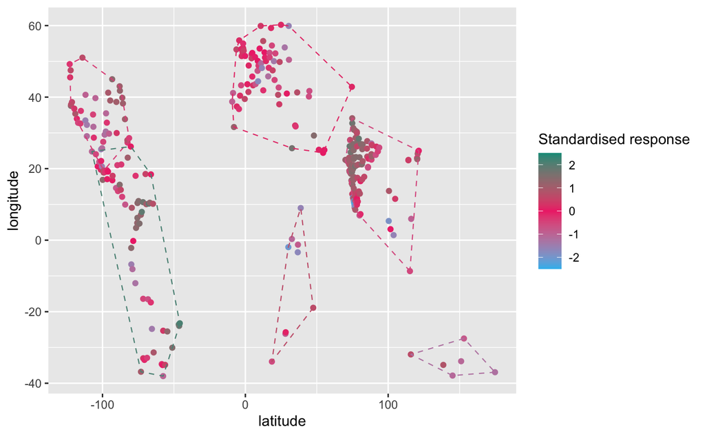

```r
with_realms_latlong(ggplot(analysis_data, aes(x = latitude, y = longitude, colour = mass_fdiv_standard)) + geom_point() + standardised_colours_scale + labs(colour = "Standardised response"))
```

```r
moran.test(analysis_data$mass_fdiv_standard, nb2listw(analysis_data_neighbours))
```

```
    Moran I test under randomisation

data:  analysis_data$mass_fdiv_standard
weights: nb2listw(analysis_data_neighbours)

Moran I statistic standard deviate = 9.1521, p-value < 0.00000000000000022
alternative hypothesis: greater
sample estimates:
Moran I statistic       Expectation          Variance
      0.661355126      -0.003257329       0.005273416
```

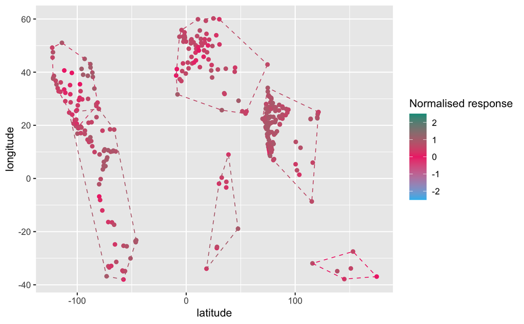

```r
with_realms_latlong(ggplot(analysis_data, aes(x = latitude, y = longitude, colour = mass_fdiv_normal)) + geom_point() + standardised_colours_scale + labs(colour = "Normalised response"))
```

```r
moran.test(analysis_data$mass_fdiv_normal, nb2listw(analysis_data_neighbours))
```

```
    Moran I test under randomisation

data:  analysis_data$mass_fdiv_normal
weights: nb2listw(analysis_data_neighbours)

Moran I statistic standard deviate = 9.008, p-value < 0.00000000000000022
alternative hypothesis: greater
sample estimates:
Moran I statistic       Expectation          Variance
      0.650776207      -0.003257329       0.005271668
```

### NMDS

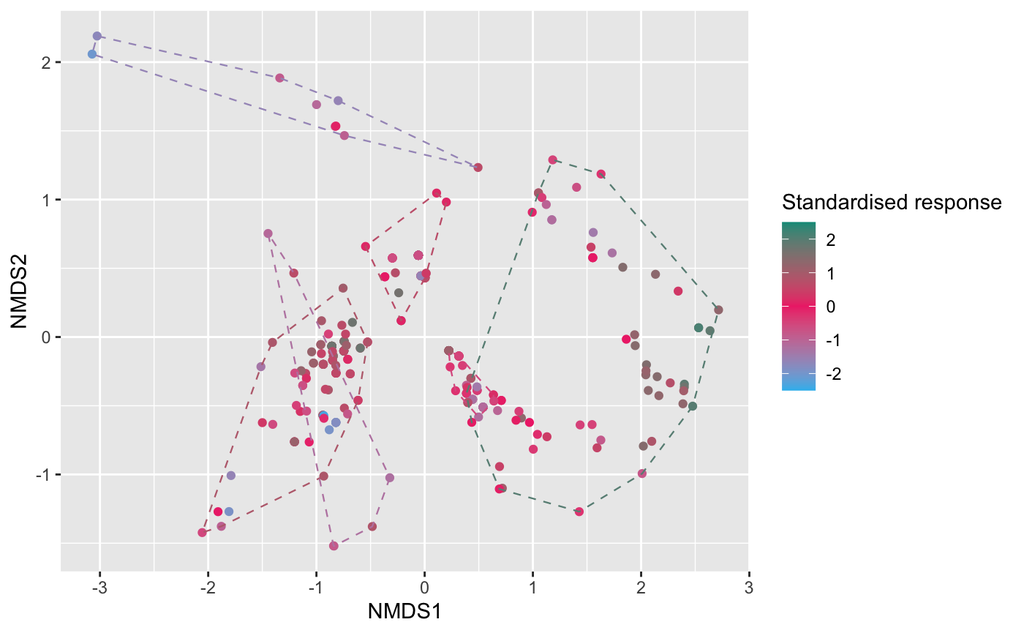

```r
with_realms_nmds(ggplot(analysis_data, aes(x = NMDS1, y = NMDS2, colour = mass_fdiv_standard)) + geom_point() + standardised_colours_scale + labs(colour = "Standardised response"))
```

```r
moran.test(analysis_data$mass_fdiv_standard, nb2listw(analysis_data_nmds_neighbours))
```

```
    Moran I test under randomisation

data:  analysis_data$mass_fdiv_standard
weights: nb2listw(analysis_data_nmds_neighbours)

Moran I statistic standard deviate = 6.2114, p-value = 0.0000000002625
alternative hypothesis: greater
sample estimates:
Moran I statistic       Expectation          Variance
      0.424488243      -0.003257329       0.004742312
```

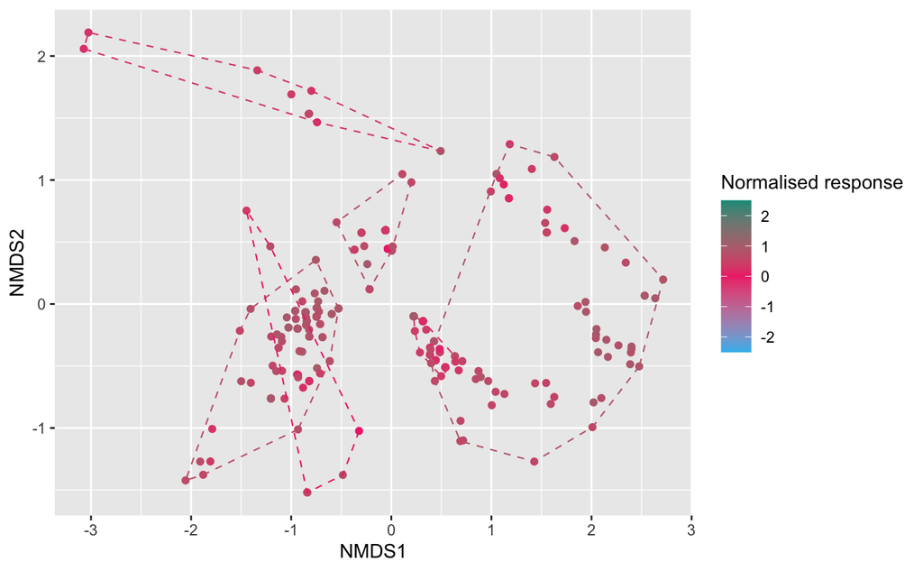

```r
with_realms_nmds(ggplot(analysis_data, aes(x = NMDS1, y = NMDS2, colour = mass_fdiv_normal)) + geom_point() + standardised_colours_scale + labs(colour = "Normalised response"))
```

```r
moran.test(analysis_data$mass_fdiv_normal, nb2listw(analysis_data_nmds_neighbours))
```

```
    Moran I test under randomisation

data:  analysis_data$mass_fdiv_normal
weights: nb2listw(analysis_data_nmds_neighbours)

Moran I statistic standard deviate = 4.6538, p-value = 0.000001629
alternative hypothesis: greater
sample estimates:
Moran I statistic       Expectation          Variance
      0.317170749      -0.003257329       0.004740769
```

# Examine individual metrics

```r
all_explanatories = c(
    'city_avg_ndvi', 'city_avg_elevation', 'city_avg_temp',
    'region_50km_avg_soil_moisture',
    'core_realmAfrotropic', 'core_realmAustralasia', 'core_realmIndomalayan', 'core_realmNearctic', 'core_realmNeotropic', 'core_realmPalearctic',
    'has_introduced_speciesNo introduced species', 'has_introduced_speciesIntroduced species',
    'core_realmAfrotropic:has_introduced_speciesIntroduced species',
    'core_realmAustralasia:has_introduced_speciesIntroduced species',
    'core_realmIndomalayan:has_introduced_speciesIntroduced species',
    'core_realmNearctic:has_introduced_speciesIntroduced species',
    'core_realmNeotropic:has_introduced_speciesIntroduced species',
    'core_realmPalearctic:has_introduced_speciesIntroduced species',
    'core_realmOceania:has_introduced_speciesIntroduced species'
)

all_explanatory_names = factor(
   c(
    'Avg. NDVI', 'Avg. Elevation', 'Avg. Temp.',
    'Avg. Soil Moisture',
    'Afrotropic', 'Australasia', 'Indomalayan', 'Nearctic', 'Neotropic', 'Palearctic',
    'Introduced Absent', 'Non-native Present',
    'Afrotropical * Non-native present',
    'Austaliasian * Non-native present',
    'Indomalayan * Non-native present',
    'Nearctic * Non-native present',
    'Neotropical * Non-native present',
    'Palearctic * Non-native present',
    'Oceanical * Non-native present'
  ), ordered = T
)

explanatory_dictionary = data.frame(explanatory = all_explanatories, explanatory_name = all_explanatory_names)

with_explanatory_type_labels = function(p) {
  p = p[p$explanatory != '(Intercept)',]
  explanatory_levels = all_explanatories[all_explanatories %in% p$explanatory]
  p$explanatory <- factor(p$explanatory, levels = explanatory_levels)

  p$type <- 'Realm'
  p$type[p$explanatory %in% c('city_avg_ndvi', 'city_avg_elevation', 'city_avg_temp')] <- 'City geography'
  p$type[p$explanatory %in% c('region_50km_avg_soil_moisture')] <- 'Regional (50 km) geography'
  p$type[p$explanatory %in% c('has_introduced_speciesNo introduced species', 'has_introduced_speciesIntroduced species')] <- 'Introduced species'
  p
}

with_explanatory_names = function(p) {
  p %>% left_join(explanatory_dictionary) %>% arrange(desc(explanatory_name))
}

type_labels = function(p) {
  explanatory_levels = all_explanatories[all_explanatories %in% p$explanatory]
  p$explanatory <- factor(p$explanatory, levels = explanatory_levels)

  p$type <- 'Realm'
  p$type[p$explanatory %in% c('city_avg_ndvi', 'city_avg_elevation', 'city_avg_temp', 'city_avg_min_monthly_temp', 'city_avg_max_monthly_temp',
    'city_avg_monthly_temp', 'city_avg_rainfall', 'city_avg_max_monthly_rainfall', 'city_avg_min_monthly_rainfall',
    'city_avg_soil_moisture', 'city_max_elev', 'city_min_elev', 'city_elev_range')] <- 'City geography'
  p$type[p$explanatory %in% c('region_50km_avg_ndvi', 'region_50km_avg_elevation', 'region_50km_avg_soil_moisture', 'region_50km_max_elev',
    'region_50km_min_elev', 'region_50km_elev_range')] <- 'Regional (50 km) geography'
   p$type[p$explanatory %in% c('region_20km_avg_ndvi', 'region_20km_avg_elevation', 'region_20km_avg_soil_moisture', 'region_20km_max_elev',
    'region_20km_min_elev', 'region_20km_elev_range')] <- 'Regional (20 km) geography'
  p$type[p$explanatory %in% c('has_introduced_speciesNo introduced species', 'has_introduced_speciesIntroduced species')] <- 'Introduced species'
  p
}
```

```r
explanatory_labels = c(
  'has_introduced_species'='Non-native species',
  'has_introduced_speciesNo introduced species'='Introduced absent',
  'has_introduced_speciesIntroduced species'='Non-native present',
  'city_avg_ndvi'='Average NDVI',
  'city_avg_elevation'='Average elevation',
  'city_avg_temp'='Average temperature',
  'city_avg_min_monthly_temp'='Average minimum monthly temperature',
  'city_avg_max_monthly_temp'='Average maximum monthly temperature',
  'city_avg_monthly_temp'='Average monthly temperature',
  'city_avg_rainfall'='Average rainfall',
  'city_avg_max_monthly_rainfall'='Average maximum monthly rainfall',
  'city_avg_min_monthly_rainfall'='Average minimum monthly rainfall',
  'city_avg_soil_moisture'='Average soil moisture',
  'city_max_elev'='Maximum elevation',
  'city_min_elev'='Minimum elevation',
  'city_elev_range'='Elevation range',
  'region_20km_avg_ndvi'='Average NDVI',
  'region_20km_avg_elevation'='Average elevation',
  'region_20km_avg_soil_moisture'='Average soil moisture',
  'region_20km_max_elev'='Maximum elevation',
  'region_20km_min_elev'='Minimum elevation',
  'region_20km_elev_range'='Elevation range',
  'region_50km_avg_ndvi'='Average NDVI',
  'region_50km_avg_elevation'='Average elevation',
  'region_50km_avg_soil_moisture'='Average soil moisture',
  'region_50km_max_elev'='Maximum elevation',
  'region_50km_min_elev'='Minimum elevation',
  'region_50km_elev_range'='Elevation range',
  'abs_latitude' = 'Absolute latitude',
  'latitude' = 'Latitude',
  'longitude' = 'Longitude',
  'core_realmAfrotropic' = 'Afrotropical',
  'core_realmAustralasia' = 'Austaliasian',
  'core_realmIndomalayan' = 'Indomalayan',
  'core_realmNearctic' = 'Nearctic',
  'core_realmNeotropic' = 'Neotropical',
  'core_realmPalearctic' = 'Palearctic',
  'core_realmOceania' = 'Oceanical',
  'core_realmAfrotropic:has_introduced_speciesIntroduced species' = 'Afrotropical * Non-native present',
  'core_realmAustralasia:has_introduced_speciesIntroduced species' = 'Austaliasian * Non-native present',
  'core_realmIndomalayan:has_introduced_speciesIntroduced species' = 'Indomalayan * Non-native present',
  'core_realmNearctic:has_introduced_speciesIntroduced species' = 'Nearctic * Non-native present',
  'core_realmNeotropic:has_introduced_speciesIntroduced species' = 'Neotropical * Non-native present',
  'core_realmPalearctic:has_introduced_speciesIntroduced species' = 'Palearctic * Non-native present',
  'core_realmOceania:has_introduced_speciesIntroduced species' = 'Oceanical * Non-native present'
)
```

```r
create_formula = function(response_var) {
  as.formula(paste(response_var, '~ core_realm + city_avg_ndvi + city_avg_elevation + city_avg_temp + region_50km_avg_soil_moisture + has_introduced_species'))
}
```

## Helper plot functions

```r
geom_map = function(map_sf, title, scale = standardised_colours_scale, colour_label = 'Standardised\nResponse') {
  norm_mntd_analysis_geo = ggplot() +
    geom_sf(data = world_map, aes(geometry = geometry), fill = 'grey95') +
    map_sf +
    scale +
    labs(colour = colour_label) +
    theme_bw() +
    theme(legend.position="bottom",
          panel.border = element_blank(),
          panel.grid.major = element_blank(),
          panel.grid.minor = element_blank(),
          axis.line = element_line(colour = "black")
    )
}

geom_map_std = function(map_sf, title) {
  geom_map(map_sf, title)
}

geom_map_nrm = function(map_sf, title) {
  geom_map(map_sf, title, normalised_colours_scale, 'Normalised\nResponse')
}
```

## Helper Dredge functions

```r
# Taken from MuMIN package
# https://rdrr.io/cran/MuMIn/src/R/averaging.R
# https://rdrr.io/cran/MuMIn/src/R/model.avg.R

.coefarr.avg <-
  function(cfarr, weight, revised.var, full, alpha) {
    weight <- weight / sum(weight)
    nCoef <- dim(cfarr)[3L]
    if(full) {
      nas <- is.na(cfarr[, 1L, ]) & is.na(cfarr[, 2L, ])
      cfarr[, 1L, ][nas] <- cfarr[, 2L, ][nas] <- 0
      #cfarr[, 1L:2L, ][is.na(cfarr[, 1L:2L, ])] <- 0
      if(!all(is.na(cfarr[, 3L, ])))
        cfarr[ ,3L, ][is.na(cfarr[ , 3L, ])] <- Inf
    }

    avgcoef <- array(dim = c(nCoef, 5L),
                     dimnames = list(dimnames(cfarr)[[3L]], c("Estimate",
                                                              "Std. Error", "Adjusted SE", "Lower CI", "Upper CI")))
    for(i in seq_len(nCoef))
      avgcoef[i, ] <- par.avg(cfarr[, 1L, i], cfarr[, 2L, i], weight,
                              df = cfarr[, 3L, i], alpha = alpha, revised.var = revised.var)

    avgcoef[is.nan(avgcoef)] <- NA
    return(avgcoef)
  }

.makecoefmat <- function(cf) {
  no.ase <- all(is.na(cf[, 3L]))
  z <- abs(cf[, 1L] / cf[, if(no.ase) 2L else 3L])
  pval <- 2 * pnorm(z, lower.tail = FALSE)
  cbind(cf[, if(no.ase) 1L:2L else 1L:3L, drop = FALSE],
        `z value` = z, `Pr(>|z|)` = zapsmall(pval))
}

# Generate model selections using lmer, dredge, and model.avg
# `forumla` : a two-sided linear formula object describing both the fixed-effects and random-effects part of the model
# `data` : the data frame containing the variables from the formula
# `aic_delta` : the AIC delta to use for selecting models in model average
model_average <- function(formula, data, aic_delta = 20) {
  model <- lm(
    formula,
    data=data
  )
  dredge_result <- dredge(model)
  summary(model.avg(dredge_result, subset = delta < aic_delta))
}

# Create a summary data frame containing the selected variables from a model
# `model_sum` : The model summary output from `model_average`
model_summary <- function(model_sum) {
  .column_name <- function(postfix) {
    postfix
  }

  # just return the estimate and p value
  weight <- model_sum$msTable[, 5L]

  coefmat.full <- as.data.frame(.makecoefmat(.coefarr.avg(model_sum$coefArray, weight,
                                                          attr(model_sum, "revised.var"), TRUE, 0.05)))

  coefmat.subset <-
    as.data.frame(.makecoefmat(.coefarr.avg(model_sum$coefArray, weight,
                                            attr(model_sum, "revised.var"), FALSE, 0.05)))


  coefmat.subset <- coefmat.subset[-c(1), c(1, 2, 5)]
  names(coefmat.subset) <- c(.column_name("estimate"), .column_name("error"), .column_name("p"))
  coefmat.subset <- tibble::rownames_to_column(coefmat.subset, "explanatory")
  coefmat.subset$model = 'subset'

  coefmat.full <- coefmat.full[-c(1), c(1, 2, 5)]
  names(coefmat.full) <- c(.column_name("estimate"), .column_name("error"), .column_name("p"))
  coefmat.full <- tibble::rownames_to_column(coefmat.full, "explanatory")
  coefmat.full$model = 'full'

  rbind(coefmat.full, coefmat.subset)
}
```

```r
plot_dredge_result = function(result_table, mu = 0) {
  p = result_table[result_table$model == 'full',]
  p = type_labels(p)

  ggplot(p, aes(y = explanatory, x = estimate, colour = type)) +
    geom_line() +
    geom_point() +
    geom_errorbar(aes(xmin=estimate-error, xmax=estimate+error), width=.2,
                   position=position_dodge(0.05)) +
    scale_y_discrete(
      limits = rev(levels(p$explanatory)),
      labels = explanatory_labels) +
    scale_colour_manual(
      labels = c('Realm', 'City geography', 'Regional (50 km) geography', 'Regional (20 km) geography', 'Non-native species'),
      values = c(realm_colour, city_geography_colour, regional_50km_geography_colour, regional_20km_geography_colour, introduced_species_colour),
      breaks = c('Realm', 'City geography', 'Regional (50 km) geography', 'Regional (20 km) geography', 'Introduced species')) +
    theme_bw() +
    geom_vline(xintercept=mu, linetype="dotted") +
    guides(colour=guide_legend(title="Predictor type")) + xlab('Difference in response from 0\nhabitat filtering (< 0) and competitive interactions (> 0)\n± Standard Error') + ylab('Predictor') +
    theme(legend.justification = "top")
}
```

## GLS Spatial Helpers

```r
gls_method = "ML"

spatial_model = function(formula, correlation) {
  gls(
    formula,
    data = analysis_data,
    correlation = correlation,
    method = gls_method
  )
}

plot_spatial_result = function(model_result) {
  model_summary = summary(model_result)
  result_table = as.data.frame(model_summary$tTable)
  result_table$explanatory = rownames(result_table)

  result_table = result_table %>% with_explanatory_type_labels() %>% with_explanatory_names()

  ggplot2::ggplot(result_table, ggplot2::aes(y=factor(explanatory_name, level = all_explanatory_names, ordered = T), x=Value, colour = type)) +
    ggplot2::geom_line() +
    ggplot2::geom_point() +
    ggplot2::geom_errorbar(ggplot2::aes(xmin=Value-Std.Error, xmax=Value+Std.Error), width=.2,
                   position=ggplot2::position_dodge(0.05)) +
    ggplot2::theme_bw() +
    ggplot2::geom_vline(xintercept=0, linetype="dotted") +
    ggplot2::theme(legend.justification = "top") +
    ylab('Predictor') +
    guides(colour=guide_legend(title="Predictor type")) + xlab('Difference in response from 0\nhabitat filtering (< 0) and competitive interactions (> 0)\n± Standard Error') +
    scale_colour_manual(
      labels = c('Realm', 'City geography', 'Regional (50 km) geography', 'Non-native species'),
      values = c(realm_colour, city_geography_colour, regional_50km_geography_colour, introduced_species_colour),
      breaks = c('Realm', 'City geography', 'Regional (50 km) geography', 'Introduced species')) +
    scale_y_discrete(limits = rev(all_explanatory_names[all_explanatory_names %in% result_table$explanatory_name]))
}
```

### Choose best spatial correlation function

#### MNTD

```r
AIC(spatial_model(create_formula('mntd_standard'), corLin(form = ~ NMDS1 + NMDS2 + latitude + longitude)))
```

```
[1] 661.8901
```

```r
AIC(spatial_model(create_formula('mntd_standard'), corLin(form = ~ latitude + longitude)))
```

```
[1] 666.4295
```

```r
AIC(spatial_model(create_formula('mntd_standard'), corExp(form = ~ NMDS1 + NMDS2 + latitude + longitude)))
```

```
[1] 653.0099
```

```r
AIC(spatial_model(create_formula('mntd_standard'), corExp(form = ~ latitude + longitude)))
```

```
[1] 656.6118
```

```r
AIC(spatial_model(create_formula('mntd_standard'), corGaus(form = ~ NMDS1 + NMDS2 + latitude + longitude)))
```

```
[1] 657.7216
```

```r
AIC(spatial_model(create_formula('mntd_standard'), corGaus(form = ~ latitude + longitude)))
```

```
[1] 662.5602
```

```r
AIC(spatial_model(create_formula('mntd_standard'), corRatio(form = ~ NMDS1 + NMDS2 + latitude + longitude)))
```

```
[1] 650.3759
```

```r
AIC(spatial_model(create_formula('mntd_standard'), corRatio(form = ~ latitude + longitude)))
```

```
[1] 654.8339
```

```r
AIC(spatial_model(create_formula('mntd_standard'), corSpher(form = ~ NMDS1 + NMDS2 + latitude + longitude)))
```

```
[1] 659.8723
```

```r
AIC(spatial_model(create_formula('mntd_standard'), corSpher(form = ~ latitude + longitude)))
```

```
[1] 664.1159
```

MNTD: corRatio with NMDS + lat/long

```r
AIC(spatial_model(create_formula('mntd_normal'), corLin(form = ~ NMDS1 + NMDS2 + latitude + longitude)))
```

```
[1] -81.16061
```

```r
#AIC(spatial_model(create_formula('mntd_normal'), corLin(form = ~ latitude + longitude)))
AIC(spatial_model(create_formula('mntd_normal'), corExp(form = ~ NMDS1 + NMDS2 + latitude + longitude)))
```

```
[1] -89.28852
```

```r
AIC(spatial_model(create_formula('mntd_normal'), corExp(form = ~ latitude + longitude)))
```

```
[1] -86.17138
```

```r
AIC(spatial_model(create_formula('mntd_normal'), corGaus(form = ~ NMDS1 + NMDS2 + latitude + longitude)))
```

```
[1] -86.02288
```

```r
AIC(spatial_model(create_formula('mntd_normal'), corGaus(form = ~ latitude + longitude)))
```

```
[1] -79.92235
```

```r
AIC(spatial_model(create_formula('mntd_normal'), corRatio(form = ~ NMDS1 + NMDS2 + latitude + longitude)))
```

```
[1] -92.46759
```

```r
AIC(spatial_model(create_formula('mntd_normal'), corRatio(form = ~ latitude + longitude)))
```

```
[1] -86.60443
```

```r
AIC(spatial_model(create_formula('mntd_normal'), corSpher(form = ~ NMDS1 + NMDS2 + latitude + longitude)))
```

```
[1] -86.78558
```

```r
AIC(spatial_model(create_formula('mntd_normal'), corSpher(form = ~ latitude + longitude)))
```

```
[1] -81.47393
```

#### Beak Width

```r
AIC(spatial_model(create_formula('beak_width_fdiv_standard'), corLin(form = ~ NMDS1 + NMDS2 + latitude + longitude)))
```

```
[1] 793.5251
```

```r
#AIC(spatial_model(create_formula('beak_width_fdiv_standard'), corLin(form = ~ latitude + longitude)))
AIC(spatial_model(create_formula('beak_width_fdiv_standard'), corExp(form = ~ NMDS1 + NMDS2 + latitude + longitude)))
```

```
[1] 789.282
```

```r
AIC(spatial_model(create_formula('beak_width_fdiv_standard'), corExp(form = ~ latitude + longitude)))
```

```
[1] 790.0085
```

```r
AIC(spatial_model(create_formula('beak_width_fdiv_standard'), corGaus(form = ~ NMDS1 + NMDS2 + latitude + longitude)))
```

```
[1] 793.7668
```

```r
AIC(spatial_model(create_formula('beak_width_fdiv_standard'), corGaus(form = ~ latitude + longitude)))
```

```
[1] 793.7656
```

```r
AIC(spatial_model(create_formula('beak_width_fdiv_standard'), corRatio(form = ~ NMDS1 + NMDS2 + latitude + longitude)))
```

```
[1] 791.2572
```

```r
AIC(spatial_model(create_formula('beak_width_fdiv_standard'), corRatio(form = ~ latitude + longitude)))
```

```
[1] 791.3899
```

```r
AIC(spatial_model(create_formula('beak_width_fdiv_standard'), corSpher(form = ~ NMDS1 + NMDS2 + latitude + longitude)))
```

```
[1] 793.8106
```

```r
AIC(spatial_model(create_formula('beak_width_fdiv_standard'), corSpher(form = ~ latitude + longitude)))
```

```
[1] 793.8106
```

Beak width: corExp with NMDS + lat/long

```r
AIC(spatial_model(create_formula('beak_width_fdiv_normal'), corLin(form = ~ NMDS1 + NMDS2 + latitude + longitude)))
```

```
[1] -45.30823
```

```r
AIC(spatial_model(create_formula('beak_width_fdiv_normal'), corLin(form = ~ latitude + longitude)))
```

```
[1] -45.30823
```

```r
AIC(spatial_model(create_formula('beak_width_fdiv_normal'), corExp(form = ~ NMDS1 + NMDS2 + latitude + longitude)))
```

```
[1] -51.4648
```

```r
AIC(spatial_model(create_formula('beak_width_fdiv_normal'), corExp(form = ~ latitude + longitude)))
```

```
[1] -50.46273
```

```r
AIC(spatial_model(create_formula('beak_width_fdiv_normal'), corGaus(form = ~ NMDS1 + NMDS2 + latitude + longitude)))
```

```
[1] -45.13365
```

```r
AIC(spatial_model(create_formula('beak_width_fdiv_normal'), corGaus(form = ~ latitude + longitude)))
```

```
[1] -45.13552
```

```r
AIC(spatial_model(create_formula('beak_width_fdiv_normal'), corRatio(form = ~ NMDS1 + NMDS2 + latitude + longitude)))
```

```
[1] -47.44015
```

```r
AIC(spatial_model(create_formula('beak_width_fdiv_normal'), corRatio(form = ~ latitude + longitude)))
```

```
[1] -47.368
```

```r
AIC(spatial_model(create_formula('beak_width_fdiv_normal'), corSpher(form = ~ NMDS1 + NMDS2 + latitude + longitude)))
```

```
[1] -44.97422
```

```r
AIC(spatial_model(create_formula('beak_width_fdiv_normal'), corSpher(form = ~ latitude + longitude)))
```

```
[1] -44.97475
```

#### HWI

```r
AIC(spatial_model(create_formula('hwi_fdiv_standard'), corLin(form = ~ NMDS1 + NMDS2 + latitude + longitude)))
```

```
[1] 694.55
```

```r
AIC(spatial_model(create_formula('hwi_fdiv_standard'), corLin(form = ~ latitude + longitude)))
```

```
[1] 699.3174
```

```r
AIC(spatial_model(create_formula('hwi_fdiv_standard'), corExp(form = ~ NMDS1 + NMDS2 + latitude + longitude)))
```

```
[1] 666.6631
```

```r
AIC(spatial_model(create_formula('hwi_fdiv_standard'), corExp(form = ~ latitude + longitude)))
```

```
[1] 671.4924
```

```r
AIC(spatial_model(create_formula('hwi_fdiv_standard'), corGaus(form = ~ NMDS1 + NMDS2 + latitude + longitude)))
```

```
[1] 704.4854
```

```r
AIC(spatial_model(create_formula('hwi_fdiv_standard'), corGaus(form = ~ latitude + longitude)))
```

```
[1] 709.2567
```

```r
AIC(spatial_model(create_formula('hwi_fdiv_standard'), corRatio(form = ~ NMDS1 + NMDS2 + latitude + longitude)))
```

```
[1] 685.5013
```

```r
AIC(spatial_model(create_formula('hwi_fdiv_standard'), corRatio(form = ~ latitude + longitude)))
```

```
[1] 690.9801
```

```r
AIC(spatial_model(create_formula('hwi_fdiv_standard'), corSpher(form = ~ NMDS1 + NMDS2 + latitude + longitude)))
```

```
[1] 689.5034
```

```r
AIC(spatial_model(create_formula('hwi_fdiv_standard'), corSpher(form = ~ latitude + longitude)))
```

```
[1] 707.7108
```

HWI: corExp with NMDS + lat/long

```r
#AIC(spatial_model(create_formula('hwi_fdiv_normal'), corLin(form = ~ NMDS1 + NMDS2 + latitude + longitude)))
#AIC(spatial_model(create_formula('hwi_fdiv_normal'), corLin(form = ~ latitude + longitude)))
AIC(spatial_model(create_formula('hwi_fdiv_normal'), corExp(form = ~ NMDS1 + NMDS2 + latitude + longitude)))
```

```
[1] -96.05945
```

```r
AIC(spatial_model(create_formula('hwi_fdiv_normal'), corExp(form = ~ latitude + longitude)))
```

```
[1] -91.16342
```

```r
AIC(spatial_model(create_formula('hwi_fdiv_normal'), corGaus(form = ~ NMDS1 + NMDS2 + latitude + longitude)))
```

```
[1] -54.57955
```

```r
AIC(spatial_model(create_formula('hwi_fdiv_normal'), corGaus(form = ~ latitude + longitude)))
```

```
[1] -50.52492
```

```r
AIC(spatial_model(create_formula('hwi_fdiv_normal'), corRatio(form = ~ NMDS1 + NMDS2 + latitude + longitude)))
```

```
[1] -74.90875
```

```r
AIC(spatial_model(create_formula('hwi_fdiv_normal'), corRatio(form = ~ latitude + longitude)))
```

```
[1] -69.65899
```

```r
AIC(spatial_model(create_formula('hwi_fdiv_normal'), corSpher(form = ~ NMDS1 + NMDS2 + latitude + longitude)))
```

```
[1] -53.60829
```

```r
AIC(spatial_model(create_formula('hwi_fdiv_normal'), corSpher(form = ~ latitude + longitude)))
```

```
[1] -61.05117
```

#### Mass

```r
AIC(spatial_model(create_formula('mass_fdiv_standard'), corLin(form = ~ NMDS1 + NMDS2 + latitude + longitude)))
```

```
[1] 703.1192
```

```r
#AIC(spatial_model(create_formula('mass_fdiv_standard'), corLin(form = ~ latitude + longitude)))
AIC(spatial_model(create_formula('mass_fdiv_standard'), corExp(form = ~ NMDS1 + NMDS2 + latitude + longitude)))
```

```
[1] 753.3038
```

```r
AIC(spatial_model(create_formula('mass_fdiv_standard'), corExp(form = ~ latitude + longitude)))
```

```
[1] 755.7536
```

```r
AIC(spatial_model(create_formula('mass_fdiv_standard'), corGaus(form = ~ NMDS1 + NMDS2 + latitude + longitude)))
```

```
[1] 786.6415
```

```r
AIC(spatial_model(create_formula('mass_fdiv_standard'), corGaus(form = ~ latitude + longitude)))
```

```
[1] 785.0663
```

```r
AIC(spatial_model(create_formula('mass_fdiv_standard'), corRatio(form = ~ NMDS1 + NMDS2 + latitude + longitude)))
```

```
[1] 766.9612
```

```r
AIC(spatial_model(create_formula('mass_fdiv_standard'), corRatio(form = ~ latitude + longitude)))
```

```
[1] 766.903
```

```r
AIC(spatial_model(create_formula('mass_fdiv_standard'), corSpher(form = ~ NMDS1 + NMDS2 + latitude + longitude)))
```

```
[1] 780.4268
```

```r
AIC(spatial_model(create_formula('mass_fdiv_standard'), corSpher(form = ~ latitude + longitude)))
```

```
[1] 779.8638
```

```r
#AIC(spatial_model(create_formula('mass_fdiv_normal'), corLin(form = ~ NMDS1 + NMDS2 + latitude + longitude)))
#AIC(spatial_model(create_formula('mass_fdiv_normal'), corLin(form = ~ latitude + longitude)))
AIC(spatial_model(create_formula('mass_fdiv_normal'), corExp(form = ~ NMDS1 + NMDS2 + latitude + longitude)))
```

```
[1] -49.779
```

```r
AIC(spatial_model(create_formula('mass_fdiv_normal'), corExp(form = ~ latitude + longitude)))
```

```
[1] -48.0529
```

```r
AIC(spatial_model(create_formula('mass_fdiv_normal'), corGaus(form = ~ NMDS1 + NMDS2 + latitude + longitude)))
```

```
[1] -21.84722
```

```r
AIC(spatial_model(create_formula('mass_fdiv_normal'), corGaus(form = ~ latitude + longitude)))
```

```
[1] -23.29214
```

```r
AIC(spatial_model(create_formula('mass_fdiv_normal'), corRatio(form = ~ NMDS1 + NMDS2 + latitude + longitude)))
```

```
[1] -35.17179
```

```r
AIC(spatial_model(create_formula('mass_fdiv_normal'), corRatio(form = ~ latitude + longitude)))
```

```
[1] -35.60617
```

```r
AIC(spatial_model(create_formula('mass_fdiv_normal'), corSpher(form = ~ NMDS1 + NMDS2 + latitude + longitude)))
```

```
[1] -27.00252
```

```r
AIC(spatial_model(create_formula('mass_fdiv_normal'), corSpher(form = ~ latitude + longitude)))
```

```
[1] -27.91974
```

```r
correlation_formula = as.formula('~ NMDS1 + NMDS2 + latitude + longitude')

correlation_function_fdiv = function() {
  corExp(form = correlation_formula)
}

correlation_function_mntd = function() {
  corRatio(form = correlation_formula)
}
```

## MNTD

### Standardised

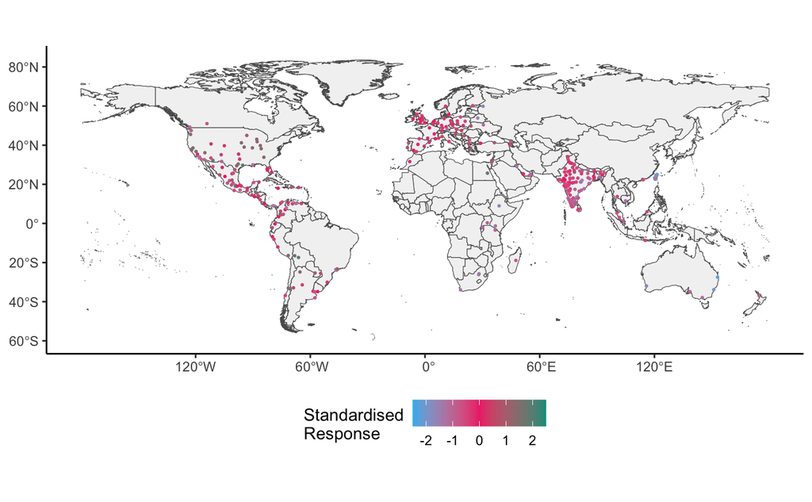

```r
POINT_SIZE = 0.4
std_mntd_analysis_geo_plot = geom_map_std(geom_sf(data = analysis_data, aes(color = mntd_standard, geometry = geometry), size = POINT_SIZE), 'MNTD')
std_mntd_analysis_geo_plot
```

```r
std_mntd_analysis_data = model_data(analysis_data[!is.na(analysis_data$mntd_standard),], 'mntd_standard')
std_mntd_analysis_formula = create_formula('mntd_standard')
std_mntd_analysis_result = model_average(std_mntd_analysis_formula, std_mntd_analysis_data)
```

```
Fixed term is "(Intercept)"
```

```r
std_mntd_analysis_result_table = model_summary(std_mntd_analysis_result)
std_mntd_analysis_result_table
```

| explanatory | estimate | error | p | model |
| --- | --- | --- | --- | --- |
| city_avg_elevation | 0.00012331256 | 0.00009602221 | 0.1998936 | full |
| city_avg_ndvi | 0.00008005147 | 0.00007122028 | 0.2617403 | full |
| core_realmNearctic | 0.43345781023 | 0.15828377878 | 0.0063549 | full |
| core_realmNeotropic | 0.12323031123 | 0.17759041029 | 0.4890412 | full |
| core_realmAfrotropic | -1.42077161200 | 0.29388187921 | 0.0000015 | full |
| core_realmIndomalayan | -0.75094597995 | 0.16784035019 | 0.0000082 | full |
| core_realmAustralasia | -1.52694010069 | 0.31668200599 | 0.0000016 | full |
| region_50km_avg_soil_moisture | -1.12177808176 | 0.93753800404 | 0.2322269 | full |
| has_introduced_speciesIntroduced species | -0.09563689499 | 0.13553141813 | 0.4812277 | full |
| city_avg_temp | -0.00032037821 | 0.00084759379 | 0.7061230 | full |

[output cut: 10 more lines]

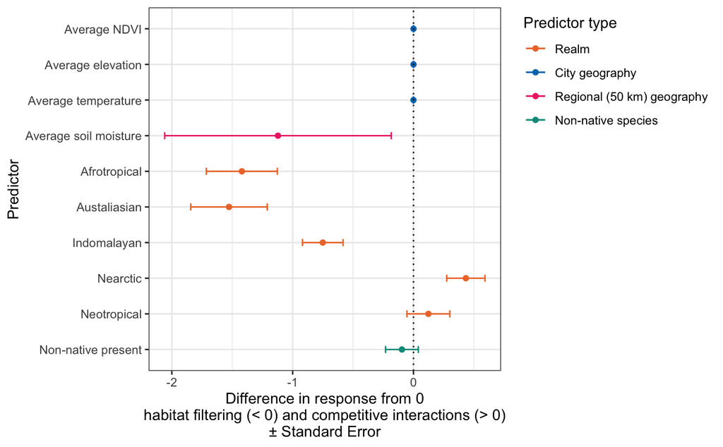

```r
std_mntd_analysis_pred_plot = plot_dredge_result(std_mntd_analysis_result_table)
std_mntd_analysis_pred_plot
```

Do the residuals still contain spatial autocorrelation from a fitted lm?

```r
std_mntd_lm = lm(std_mntd_analysis_formula, std_mntd_analysis_data)
moran.test(std_mntd_lm$residuals, nb2listw(analysis_data_neighbours))
```

```
    Moran I test under randomisation

data:  std_mntd_lm$residuals
weights: nb2listw(analysis_data_neighbours)

Moran I statistic standard deviate = 3.8425, p-value = 0.0000609
alternative hypothesis: greater
sample estimates:
Moran I statistic       Expectation          Variance
      0.275671194      -0.003257329       0.005269438
```

```r
moran.test(std_mntd_lm$residuals, nb2listw(analysis_data_nmds_neighbours))
```

```
    Moran I test under randomisation

data:  std_mntd_lm$residuals
weights: nb2listw(analysis_data_nmds_neighbours)

Moran I statistic standard deviate = 2.9566, p-value = 0.001555
alternative hypothesis: greater
sample estimates:
Moran I statistic       Expectation          Variance
      0.200271681      -0.003257329       0.004738802
```

```r
std_mntd_spatial_model = spatial_model(std_mntd_analysis_formula, correlation_function_mntd())
moran.test(std_mntd_spatial_model$residuals, nb2listw(analysis_data_neighbours))
```

```
    Moran I test under randomisation

data:  std_mntd_spatial_model$residuals
weights: nb2listw(analysis_data_neighbours)

Moran I statistic standard deviate = 4.0485, p-value = 0.00002578
alternative hypothesis: greater
sample estimates:
Moran I statistic       Expectation          Variance
      0.290664449      -0.003257329       0.005270844
```

```r
moran.test(std_mntd_spatial_model$residuals, nb2listw(analysis_data_nmds_neighbours))
```

```
    Moran I test under randomisation

data:  std_mntd_spatial_model$residuals
weights: nb2listw(analysis_data_nmds_neighbours)

Moran I statistic standard deviate = 3.1544, p-value = 0.0008041
alternative hypothesis: greater
sample estimates:
Moran I statistic       Expectation          Variance
      0.213916976      -0.003257329       0.004740043
```

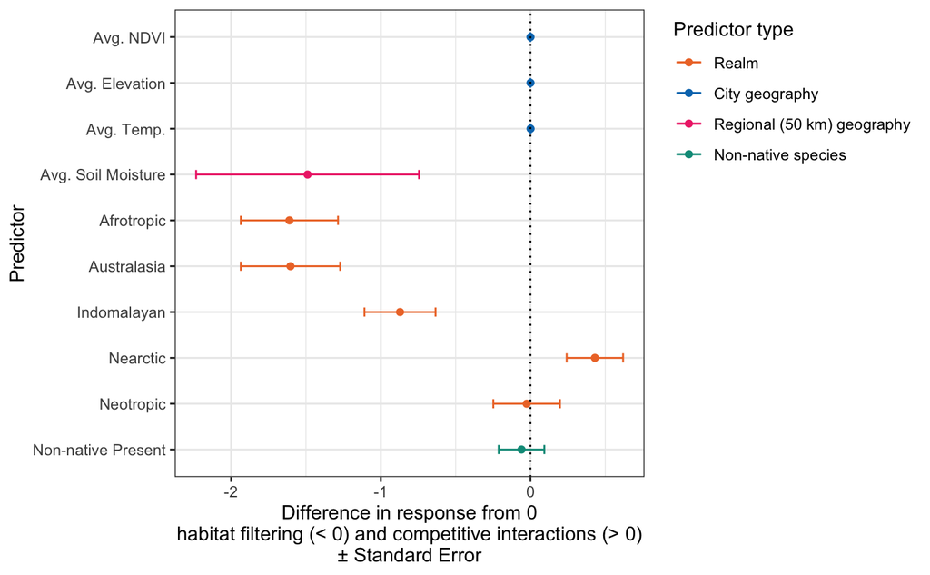

```r
std_mntd_analysis_pred_spatial_plot = plot_spatial_result(std_mntd_spatial_model)
std_mntd_analysis_pred_spatial_plot
```

### Normalised

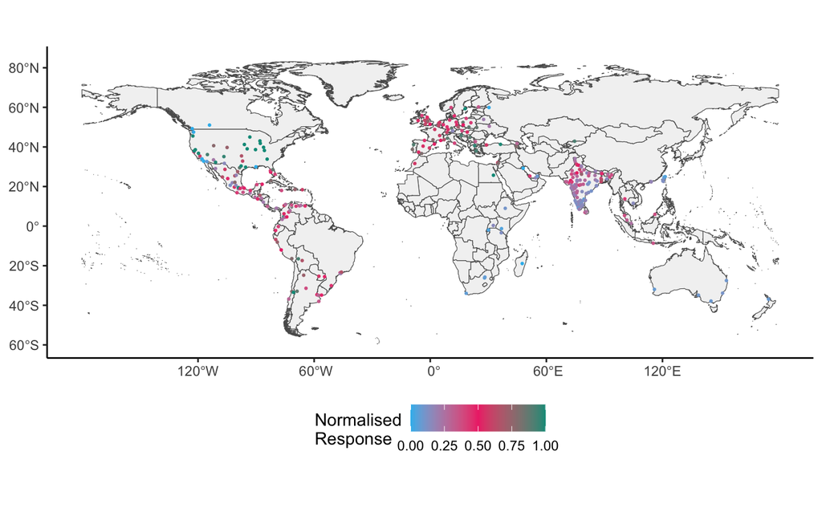

```r
nrm_mntd_analysis_geo_plot = geom_map_nrm(geom_sf(data = analysis_data, aes(color = mntd_normal, geometry = geometry), size = POINT_SIZE), 'MNTD')
nrm_mntd_analysis_geo_plot
```

```r
nrm_mntd_analysis_data = model_data(analysis_data[!is.na(analysis_data$mntd_normal),], 'mntd_normal')
```

[output not shown]

```r
nrm_mntd_analysis_formula = create_formula('mntd_normal')
nrm_mntd_analysis_result = model_average(nrm_mntd_analysis_formula, nrm_mntd_analysis_data)
```

```
Fixed term is "(Intercept)"
```

```r
nrm_mntd_analysis_result_table = model_summary(nrm_mntd_analysis_result)
nrm_mntd_analysis_result_table
```

| explanatory | estimate | error | p | model |
| --- | --- | --- | --- | --- |
| city_avg_ndvi | 0.000037676440 | 0.00002025106 | 0.0634111 | full |
| city_avg_temp | -0.000692071545 | 0.00042683287 | 0.1056717 | full |
| core_realmNearctic | 0.092121844441 | 0.04741512860 | 0.0529032 | full |
| core_realmNeotropic | -0.029546074228 | 0.06134508768 | 0.6310190 | full |
| core_realmAfrotropic | -0.473271901116 | 0.08911176624 | 0.0000001 | full |
| core_realmIndomalayan | -0.235582456228 | 0.06880143431 | 0.0006373 | full |
| core_realmAustralasia | -0.474243065468 | 0.09707178499 | 0.0000011 | full |
| region_50km_avg_soil_moisture | -0.601942680239 | 0.26523503390 | 0.0235785 | full |
| city_avg_elevation | 0.000009596207 | 0.00002008294 | 0.6335026 | full |
| has_introduced_speciesIntroduced species | -0.000390436712 | 0.02154218420 | 0.9855944 | full |

[output cut: 10 more lines]

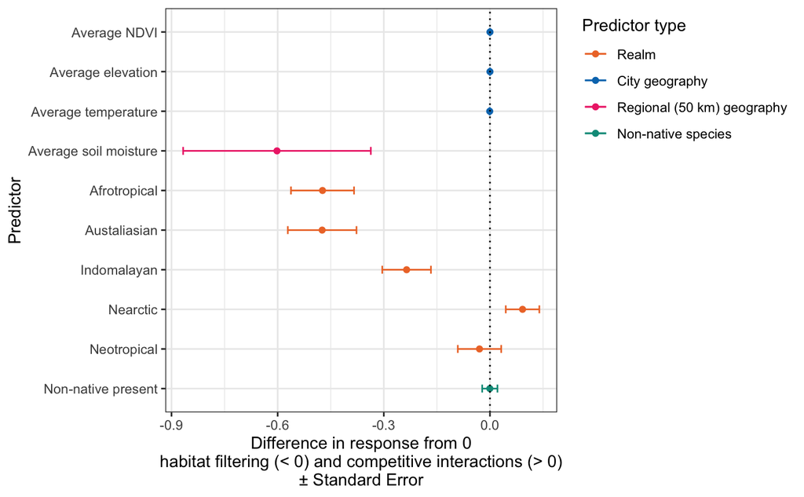

```r
nrm_mntd_analysis_pred_plot = plot_dredge_result(nrm_mntd_analysis_result_table)
nrm_mntd_analysis_pred_plot
```

Do the residuals still contain spatial autocorrelation from a fitted lm?

```r
nrm_mntd_lm = lm(nrm_mntd_analysis_formula, nrm_mntd_analysis_data)
moran.test(nrm_mntd_lm$residuals, nb2listw(analysis_data_neighbours))
```

```
    Moran I test under randomisation

data:  nrm_mntd_lm$residuals
weights: nb2listw(analysis_data_neighbours)

Moran I statistic standard deviate = 4.2864, p-value = 0.000009079
alternative hypothesis: greater
sample estimates:
Moran I statistic       Expectation          Variance
      0.307465451      -0.003257329       0.005254828
```

```r
moran.test(nrm_mntd_lm$residuals, nb2listw(analysis_data_nmds_neighbours))
```

```
    Moran I test under randomisation

data:  nrm_mntd_lm$residuals
weights: nb2listw(analysis_data_nmds_neighbours)

Moran I statistic standard deviate = 2.0944, p-value = 0.01811
alternative hypothesis: greater
sample estimates:
Moran I statistic       Expectation          Variance
      0.140725445      -0.003257329       0.004725908
```

```r
nrm_mntd_spatial_model = spatial_model(nrm_mntd_analysis_formula, correlation_function_mntd())
moran.test(nrm_mntd_spatial_model$residuals, nb2listw(analysis_data_neighbours))
```

```
    Moran I test under randomisation

data:  nrm_mntd_spatial_model$residuals
weights: nb2listw(analysis_data_neighbours)

Moran I statistic standard deviate = 4.7455, p-value = 0.00000104
alternative hypothesis: greater
sample estimates:
Moran I statistic       Expectation          Variance
      0.340740843      -0.003257329       0.005254693
```

```r
moran.test(nrm_mntd_spatial_model$residuals, nb2listw(analysis_data_nmds_neighbours))
```

```
    Moran I test under randomisation

data:  nrm_mntd_spatial_model$residuals
weights: nb2listw(analysis_data_nmds_neighbours)

Moran I statistic standard deviate = 2.3578, p-value = 0.009192
alternative hypothesis: greater
sample estimates:
Moran I statistic       Expectation          Variance
      0.158827607      -0.003257329       0.004725789
```

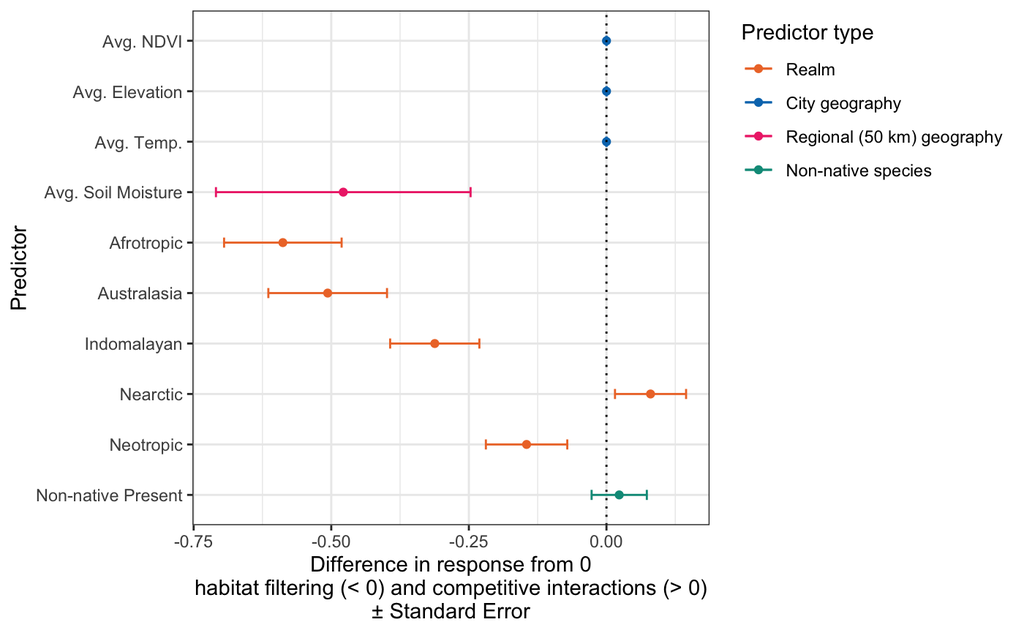

```r
nrm_mntd_analysis_pred_spatial_plot = plot_spatial_result(nrm_mntd_spatial_model)
nrm_mntd_analysis_pred_spatial_plot
```